# Experiment 1 Plots

Sanne Poelstra

14/03/2021

# Preparing the data

```r
d <- read.csv("Experiment1.csv", header = TRUE, sep = ',')
#This is quite a lot so I want to trim it somewhat, e.g. things such as font are not needed
dat <- d[, c("A", "A1", "A1_alt", "A2", "A3", "A3_alt", "B", "B1", "B1_alt", "B2", "B3", "B3_alt", "X", "X1", "X1_alt", "X2", "X3", "X3_alt", "C", "C_alt", "Outcome", "Stim1", "Stim2", "responseR1", "responseR2", "responseR3",  "block1", "block2", "block3", "average_response_time", "avg_rt", "NewAnswers", "Practice", "date_starttime", "jatosStudyResultId", "pos1X", "pos1Y", "pos2X", "pos2Y", "prolific_id", "response_time", "Cond", "Train_Test", "screen_availableHeight", "screen_availableWidth",  "timeout_occurred", "total_response_time", "Trial")]

#other things that would be interesting to look at later maybe:
```

```
#> I also have the times that people were on the (text)screens
#> There are counters for each of the screens
```

```r
head(dat)
```

```
##           A        A1       A1_alt         A2             A3             A3_alt
## 1           Acorn.png Chestnut.png Beetle.png Footprints.png BearFootprints.png
## 2           Acorn.png Chestnut.png Beetle.png Footprints.png BearFootprints.png
## 3           Acorn.png Chestnut.png Beetle.png Footprints.png BearFootprints.png
## 4           Acorn.png Chestnut.png Beetle.png Footprints.png BearFootprints.png
## 5 Acorn.png Acorn.png Chestnut.png Beetle.png Footprints.png BearFootprints.png
## 6 Acorn.png Acorn.png Chestnut.png Beetle.png Footprints.png BearFootprints.png
##         B      B1    B1_alt         B2         B3   B3_alt                X
## 1         Log.png Stump.png Puddle.png Flower.png Rose.png
## 2         Log.png Stump.png Puddle.png Flower.png Rose.png
## 3         Log.png Stump.png Puddle.png Flower.png Rose.png
## 4         Log.png Stump.png Puddle.png Flower.png Rose.png
## 5 Log.png Log.png Stump.png Puddle.png Flower.png Rose.png BlackBerries.png
## 6 Log.png Log.png Stump.png Puddle.png Flower.png Rose.png BlackBerries.png
##                 X1         X1_alt        X2          X3      X3_alt
```

[output cut: 48 more lines]

```r
###############
#now there were also some prolific IDs that were rejected, so I have to remove them
dat <- dat[which(dat$prolific_id != "5eef8aa4039a790817217ba3" & dat$prolific_id != "5eab2033f0b5cc0d9f44331d" & dat$prolific_id != "5f5624cfbb2be4a0571cb9ce" & dat$prolific_id != "60075182b660fb21ca5b3837" & dat$prolific_id != "5fabcdd6a5caa50491afce19" & dat$prolific_id != "5f93eb0c092fa01d2ed5da10" & dat$prolific_id != "5f6d9723b4a3d2212bd83eee" & dat$prolific_id != "5f6b36e1ab9578230dd425df"),]

#plus remove those that returned themselves!!
dat <- dat[which(dat$prolific_id != "601ddab3d1b8f21ea2f22865" & dat$prolific_id != "6040d72da487f5368a2eeddb" & dat$prolific_id != "5fd73d274ea4626dde59f11d" & dat$prolific_id != "5ccf6e4c222373001912f644" & dat$prolific_id != "5edb9139dc4bc502f26c4019" & dat$prolific_id != "6046740c46c42f05d552e99e" & dat$prolific_id != "5c93fd66503aea0001360bfd" & dat$prolific_id != "5f34d671952faa402de77cdc" & dat$prolific_id != "604c919f4e274caaf2502bdd" & dat$prolific_id != "5dbf4877f33f403e418eb9ac" & dat$prolific_id != "5f132e2f1e837c059737eda3" & dat$prolific_id != "5e52894c77e0502a16cb4354" & dat$prolific_id != "604ce30820ad61b5acbf037f" & dat$prolific_id != "5e8237edf80ed29537e1759b" & dat$prolific_id != "60300a6be9ee912613f17752" & dat$prolific_id != "5efd04a3b8abd1137b0ab607" & dat$prolific_id != "5f8afc0dd9375a1cc895ebe2" & dat$prolific_id != "5915bacd0a4b9d0001add6d5"),]

length(unique(dat$prolific_id))
```

```
## [1] 60
```

```r
#Note participants 5e739143d4934a023004b7fc experiment went a bit weird, she did 18 trials in the first block, 19 in the second, and the third block went fine
#Participant 5f9aba6600cdf11f1c9b915c had an extra practice run for some reason
```

```r
#As we don't know yet which condition was the first block, I'm going to have to assign a new column with that value
#blockNr depends on the value of block 1. If block 1 was 0 (internally 0 meant condition 0) and the condition of this current trial is 0, then we give this the value "block 1"

dat$blockNr <- ""
dat <- within(dat, blockNr[block1 == '0' & Cond == 0] <- 'Block1')
dat <- within(dat, blockNr[block1 == '1' & Cond == 50] <- 'Block1')
dat <- within(dat, blockNr[block1 == '2' & Cond == 100] <- 'Block1')
dat <- within(dat, blockNr[block2 == '0' & Cond == 0] <- 'Block2')
dat <- within(dat, blockNr[block2 == '1' & Cond == 50] <- 'Block2')
dat <- within(dat, blockNr[block2 == '2' & Cond == 100] <- 'Block2')
dat <- within(dat, blockNr[block3 == '0' & Cond == 0] <- 'Block3')
dat <- within(dat, blockNr[block3 == '1' & Cond == 50] <- 'Block3')
dat <- within(dat, blockNr[block3 == '2' & Cond == 100] <- 'Block3')

dat$CondFirstBlock <- ''
dat$CondSecondBlock <- ''
dat$CondThirdBlock <- ''

dat$prolific_id <- as.factor(dat$prolific_id)

#to later compare the cues in the test phase to the condition they were originally asked in, we need another new column
#so for each participant, what condition was block 1? Save that in a row, what condition was block 3?
for(i in unique(dat$prolific_id)){
  dat <- within(dat, CondFirstBlock[prolific_id == i] <- Cond[prolific_id == i & blockNr == "Block1"])
  dat <- within(dat, CondSecondBlock[prolific_id == i] <- Cond[prolific_id == i & blockNr == "Block2"])
  dat <- within(dat, CondThirdBlock[prolific_id == i] <- Cond[prolific_id == i & blockNr == "Block3"])
} #HAAKJES
```

```r
#averages per condition, for X A and B
#responseR1 is always A, R2 is always B and R3 is always X

#train is the training phase. I want to make both a plot with 1's as answers removed, and one with all the answers, so I'll create two "train" dataframes
train1 <- dat[which(dat$Train_Test == "Train"),]
train <- dat[which(dat$Train_Test == "Train"),]

#Filter the 999 ones
train$responseR1[train$responseR1 == 999] <- NA
train$responseR2[train$responseR2 == 999] <- NA
train$responseR3[train$responseR3 == 999] <- NA

train1$responseR1[train1$responseR1 == 999] <- NA
train1$responseR2[train1$responseR2 == 999] <- NA
train1$responseR3[train1$responseR3 == 999] <- NA

train1$responseR1[train$responseR1 == 1] <- NA
train1$responseR2[train$responseR2 == 1] <- NA
train1$responseR3[train$responseR3 == 1] <- NA

#I need to relevel the data as otherwise it will level it as 0, 100, 50, which will plot wrong
train$Cond <- as.factor(train$Cond)
train$Cond <- factor(train$Cond, levels = c("0", "50", "100"))

train1$Cond <- as.factor(train1$Cond)
train1$Cond <- factor(train1$Cond, levels = c("0", "50", "100"))

a <- aggregate(list(train$responseR1, train$responseR2, train$responseR3), list(train$Cond), mean, na.rm = T)
b <- aggregate(list(train1$responseR1, train1$responseR2, train1$responseR3), list(train1$Cond), mean, na.rm = T)

colnames(a) <- c("Cond", "A", "B", "X")
colnames(b) <- c("Cond", "A", "B", "X")
head(a)
```

```
##   Cond        A        B        X
## 1    0 4.261280 3.714134 4.879440
## 2   50 4.413613 3.576596 4.873526
## 3  100 4.723849 3.418947 4.790870
```

```r
head(b)
```

```
##   Cond        A        B        X
## 1    0 5.171812 4.674820 5.316168
## 2   50 5.323607 4.838352 5.307509
## 3  100 5.753004 4.862185 5.408642
```

```r
SECondA <- c(std.error(train$responseR1[train$Cond == "0"]), std.error(train$responseR1[train$Cond == "50"]), std.error(train$responseR1[train$Cond == "100"]))
SECondB <- c(std.error(train$responseR2[train$Cond == "0"]), std.error(train$responseR2[train$Cond == "50"]), std.error(train$responseR2[train$Cond == "100"]))
SECondX <- c(std.error(train$responseR3[train$Cond == "0"]), std.error(train$responseR3[train$Cond == "50"]), std.error(train$responseR3[train$Cond == "100"]))

SECondA
```

```
## [1] 0.08461671 0.08653026 0.09346249
```

```r
SECondB
```

```
## [1] 0.07859604 0.08128172 0.08250729
```

```r
SECondX
```

```
## [1] 0.07882402 0.07891390 0.08391406
```

```r
#over the 16 trials, for each of the conditions, get the average response for A, B and X
AllTrials <- aggregate(list(train$responseR1, train$responseR2, train$responseR3), list(train$Cond, train$Trial), mean, na.rm = T)
AllTrials1 <- aggregate(list(train1$responseR1, train1$responseR2, train1$responseR3), list(train1$Cond, train1$Trial), mean, na.rm = T)
colnames(AllTrials) <- c("Cond", "Trial", "A", "B", "X")
colnames(AllTrials1) <- c("Cond", "Trial", "A", "B", "X")

#Then split this into the different conditions
Cond000 <- AllTrials[which(AllTrials$Cond==0),]
Cond050 <- AllTrials[which(AllTrials$Cond==50),]
Cond100 <- AllTrials[which(AllTrials$Cond==100),]

#This is then the one without 1's
Cond0001 <- AllTrials1[which(AllTrials1$Cond==0),]
Cond0501 <- AllTrials1[which(AllTrials1$Cond==50),]
Cond1001 <- AllTrials1[which(AllTrials1$Cond==100),]

SETrials000A <- c(std.error(train$responseR1[train$Cond == "0" & train$Trial == '1']), std.error(train$responseR1[train$Cond == "0" & train$Trial == '2']), std.error(train$responseR1[train$Cond == "0" & train$Trial == '3']), std.error(train$responseR1[train$Cond == "0" & train$Trial == '4']), std.error(train$responseR1[train$Cond == "0" & train$Trial == '5']), std.error(train$responseR1[train$Cond == "0" & train$Trial == '6']), std.error(train$responseR1[train$Cond == "0" & train$Trial == '7']), std.error(train$responseR1[train$Cond == "0" & train$Trial == '8']), std.error(train$responseR1[train$Cond == "0" & train$Trial == '9']), std.error(train$responseR1[train$Cond == "0" & train$Trial == '10']), std.error(train$responseR1[train$Cond == "0" & train$Trial == '11']), std.error(train$responseR1[train$Cond == "0" & train$Trial == '12']), std.error(train$responseR1[train$Cond == "0" & train$Trial == '13']), std.error(train$responseR1[train$Cond == "0" & train$Trial == '14']), std.error(train$responseR1[train$Cond == "0" & train$Trial == '15']), std.error(train$responseR1[train$Cond == "0" & train$Trial == '16']))
SETrials000B <- c(std.error(train$responseR2[train$Cond == "0" & train$Trial == '1']), std.error(train$responseR2[train$Cond == "0" & train$Trial == '2']), std.error(train$responseR2[train$Cond == "0" & train$Trial == '3']), std.error(train$responseR2[train$Cond == "0" & train$Trial == '4']), std.error(train$responseR2[train$Cond == "0" & train$Trial == '5']), std.error(train$responseR2[train$Cond == "0" & train$Trial == '6']), std.error(train$responseR2[train$Cond == "0" & train$Trial == '7']), std.error(train$responseR2[train$Cond == "0" & train$Trial == '8']), std.error(train$responseR2[train$Cond == "0" & train$Trial == '9']), std.error(train$responseR2[train$Cond == "0" & train$Trial == '10']), std.error(train$responseR2[train$Cond == "0" & train$Trial == '11']), std.error(train$responseR2[train$Cond == "0" & train$Trial == '12']), std.error(train$responseR2[train$Cond == "0" & train$Trial == '13']), std.error(train$responseR2[train$Cond == "0" & train$Trial == '14']), std.error(train$responseR2[train$Cond == "0" & train$Trial == '15']), std.error(train$responseR2[train$Cond == "0" & train$Trial == '16']))
SETrials000X <- c(std.error(train$responseR3[train$Cond == "0" & train$Trial == '1']), std.error(train$responseR3[train$Cond == "0" & train$Trial == '2']), std.error(train$responseR3[train$Cond == "0" & train$Trial == '3']), std.error(train$responseR3[train$Cond == "0" & train$Trial == '4']), std.error(train$responseR3[train$Cond == "0" & train$Trial == '5']), std.error(train$responseR3[train$Cond == "0" & train$Trial == '6']), std.error(train$responseR3[train$Cond == "0" & train$Trial == '7']), std.error(train$responseR3[train$Cond == "0" & train$Trial == '8']), std.error(train$responseR3[train$Cond == "0" & train$Trial == '9']), std.error(train$responseR3[train$Cond == "0" & train$Trial == '10']), std.error(train$responseR3[train$Cond == "0" & train$Trial == '11']), std.error(train$responseR3[train$Cond == "0" & train$Trial == '12']), std.error(train$responseR3[train$Cond == "0" & train$Trial == '13']), std.error(train$responseR3[train$Cond == "0" & train$Trial == '14']), std.error(train$responseR3[train$Cond == "0" & train$Trial == '15']), std.error(train$responseR3[train$Cond == "0" & train$Trial == '16']))


SETrials050A <- c(std.error(train$responseR1[train$Cond == "50" & train$Trial == '1']), std.error(train$responseR1[train$Cond == "50" & train$Trial == '2']), std.error(train$responseR1[train$Cond == "50" & train$Trial == '3']), std.error(train$responseR1[train$Cond == "50" & train$Trial == '4']), std.error(train$responseR1[train$Cond == "50" & train$Trial == '5']), std.error(train$responseR1[train$Cond == "50" & train$Trial == '6']), std.error(train$responseR1[train$Cond == "50" & train$Trial == '7']), std.error(train$responseR1[train$Cond == "50" & train$Trial == '8']), std.error(train$responseR1[train$Cond == "50" & train$Trial == '9']), std.error(train$responseR1[train$Cond == "50" & train$Trial == '10']), std.error(train$responseR1[train$Cond == "50" & train$Trial == '11']), std.error(train$responseR1[train$Cond == "50" & train$Trial == '12']), std.error(train$responseR1[train$Cond == "50" & train$Trial == '13']), std.error(train$responseR1[train$Cond == "50" & train$Trial == '14']), std.error(train$responseR1[train$Cond == "50" & train$Trial == '15']), std.error(train$responseR1[train$Cond == "50" & train$Trial == '16']))
SETrials050B <- c(std.error(train$responseR2[train$Cond == "50" & train$Trial == '1']), std.error(train$responseR2[train$Cond == "50" & train$Trial == '2']), std.error(train$responseR2[train$Cond == "50" & train$Trial == '3']), std.error(train$responseR2[train$Cond == "50" & train$Trial == '4']), std.error(train$responseR2[train$Cond == "50" & train$Trial == '5']), std.error(train$responseR2[train$Cond == "50" & train$Trial == '6']), std.error(train$responseR2[train$Cond == "50" & train$Trial == '7']), std.error(train$responseR2[train$Cond == "50" & train$Trial == '8']), std.error(train$responseR2[train$Cond == "50" & train$Trial == '9']), std.error(train$responseR2[train$Cond == "50" & train$Trial == '10']), std.error(train$responseR2[train$Cond == "50" & train$Trial == '11']), std.error(train$responseR2[train$Cond == "50" & train$Trial == '12']), std.error(train$responseR2[train$Cond == "50" & train$Trial == '13']), std.error(train$responseR2[train$Cond == "50" & train$Trial == '14']), std.error(train$responseR2[train$Cond == "50" & train$Trial == '15']), std.error(train$responseR2[train$Cond == "50" & train$Trial == '16']))
SETrials050X <- c(std.error(train$responseR3[train$Cond == "50" & train$Trial == '1']), std.error(train$responseR3[train$Cond == "50" & train$Trial == '2']), std.error(train$responseR3[train$Cond == "50" & train$Trial == '3']), std.error(train$responseR3[train$Cond == "50" & train$Trial == '4']), std.error(train$responseR3[train$Cond == "50" & train$Trial == '5']), std.error(train$responseR3[train$Cond == "50" & train$Trial == '6']), std.error(train$responseR3[train$Cond == "50" & train$Trial == '7']), std.error(train$responseR3[train$Cond == "50" & train$Trial == '8']), std.error(train$responseR3[train$Cond == "50" & train$Trial == '9']), std.error(train$responseR3[train$Cond == "50" & train$Trial == '10']), std.error(train$responseR3[train$Cond == "50" & train$Trial == '11']), std.error(train$responseR3[train$Cond == "50" & train$Trial == '12']), std.error(train$responseR3[train$Cond == "50" & train$Trial == '13']), std.error(train$responseR3[train$Cond == "50" & train$Trial == '14']), std.error(train$responseR3[train$Cond == "50" & train$Trial == '15']), std.error(train$responseR3[train$Cond == "50" & train$Trial == '16']))

SETrials100A <- c(std.error(train$responseR1[train$Cond == "100" & train$Trial == '1']), std.error(train$responseR1[train$Cond == "100" & train$Trial == '2']), std.error(train$responseR1[train$Cond == "100" & train$Trial == '3']), std.error(train$responseR1[train$Cond == "100" & train$Trial == '4']), std.error(train$responseR1[train$Cond == "100" & train$Trial == '5']), std.error(train$responseR1[train$Cond == "100" & train$Trial == '6']), std.error(train$responseR1[train$Cond == "100" & train$Trial == '7']), std.error(train$responseR1[train$Cond == "100" & train$Trial == '8']), std.error(train$responseR1[train$Cond == "100" & train$Trial == '9']), std.error(train$responseR1[train$Cond == "100" & train$Trial == '10']), std.error(train$responseR1[train$Cond == "100" & train$Trial == '11']), std.error(train$responseR1[train$Cond == "100" & train$Trial == '12']), std.error(train$responseR1[train$Cond == "100" & train$Trial == '13']), std.error(train$responseR1[train$Cond == "100" & train$Trial == '14']), std.error(train$responseR1[train$Cond == "100" & train$Trial == '15']), std.error(train$responseR1[train$Cond == "100" & train$Trial == '16']))
SETrials100B <- c(std.error(train$responseR2[train$Cond == "100" & train$Trial == '1']), std.error(train$responseR2[train$Cond == "100" & train$Trial == '2']), std.error(train$responseR2[train$Cond == "100" & train$Trial == '3']), std.error(train$responseR2[train$Cond == "100" & train$Trial == '4']), std.error(train$responseR2[train$Cond == "100" & train$Trial == '5']), std.error(train$responseR2[train$Cond == "100" & train$Trial == '6']), std.error(train$responseR2[train$Cond == "100" & train$Trial == '7']), std.error(train$responseR2[train$Cond == "100" & train$Trial == '8']), std.error(train$responseR2[train$Cond == "100" & train$Trial == '9']), std.error(train$responseR2[train$Cond == "100" & train$Trial == '10']), std.error(train$responseR2[train$Cond == "100" & train$Trial == '11']), std.error(train$responseR2[train$Cond == "100" & train$Trial == '12']), std.error(train$responseR2[train$Cond == "100" & train$Trial == '13']), std.error(train$responseR2[train$Cond == "100" & train$Trial == '14']), std.error(train$responseR2[train$Cond == "100" & train$Trial == '15']), std.error(train$responseR2[train$Cond == "100" & train$Trial == '16']))
SETrials100X <- c(std.error(train$responseR3[train$Cond == "100" & train$Trial == '1']), std.error(train$responseR3[train$Cond == "100" & train$Trial == '2']), std.error(train$responseR3[train$Cond == "100" & train$Trial == '3']), std.error(train$responseR3[train$Cond == "100" & train$Trial == '4']), std.error(train$responseR3[train$Cond == "100" & train$Trial == '5']), std.error(train$responseR3[train$Cond == "100" & train$Trial == '6']), std.error(train$responseR3[train$Cond == "100" & train$Trial == '7']), std.error(train$responseR3[train$Cond == "100" & train$Trial == '8']), std.error(train$responseR3[train$Cond == "100" & train$Trial == '9']), std.error(train$responseR3[train$Cond == "100" & train$Trial == '10']), std.error(train$responseR3[train$Cond == "100" & train$Trial == '11']), std.error(train$responseR3[train$Cond == "100" & train$Trial == '12']), std.error(train$responseR3[train$Cond == "100" & train$Trial == '13']), std.error(train$responseR3[train$Cond == "100" & train$Trial == '14']), std.error(train$responseR3[train$Cond == "100" & train$Trial == '15']), std.error(train$responseR3[train$Cond == "100" & train$Trial == '16']))


SETrials000A
```

```
##  [1] 0.3180877 0.3463365 0.3397463 0.3393455 0.3164882 0.3501945 0.3210960
##  [8] 0.3204869 0.3533269 0.3121745 0.3299261 0.3257326 0.3395674 0.3497107
## [15] 0.3543847 0.3448300
```

```r
SETrials000B
```

```
##  [1] 0.3373468 0.2689314 0.3050568 0.3094211 0.2951664 0.3261423 0.3590633
##  [8] 0.2916042 0.3049729 0.3134132 0.3016275 0.3335182 0.2865498 0.2925551
## [15] 0.3538807 0.2668079
```

```r
SETrials000X
```

```
##  [1] 0.3687350 0.3241140 0.3235438 0.3197881 0.3332508 0.3121628 0.3178229
##  [8] 0.3302499 0.3116991 0.2834389 0.2801473 0.3151764 0.3184458 0.3020333
## [15] 0.3276817 0.2925369
```

```r
#For cues from A the SE is quite similar

SETrials050A
```

```
##  [1] 0.3467977 0.3202688 0.3621122 0.2834738 0.2925310 0.3273114 0.3197516
##  [8] 0.3268508 0.3704225 0.3242476 0.3545519 0.3139791 0.3267716 0.3621122
## [15] 0.2935191 0.3484969
```

```r
SETrials050B
```

```
##  [1] 0.3612030 0.3409644 0.3005443 0.3008150 0.2666039 0.2961832 0.3538247
##  [8] 0.3196632 0.2925551 0.3762925 0.3037354 0.3341562 0.2718796 0.3251177
## [15] 0.3431053 0.3164642
```

```r
SETrials050X
```

```
##  [1] 0.3302045 0.3303818 0.3260143 0.3134606 0.3034896 0.2859251 0.3014426
##  [8] 0.3050115 0.3011200 0.3334142 0.3065262 0.3003562 0.3300098 0.2837319
## [15] 0.3039213 0.3083978
```

```r
#Same here, also when compared to 000


SETrials100A
```

```
##  [1] 0.3428789 0.3297245 0.3520424 0.3306317 0.3296049 0.3418367 0.3273274
##  [8] 0.3922207 0.4144063 0.3510208 0.3932337 0.3513805 0.3467362 0.3938020
## [15] 0.3540066 0.4165137
```

```r
SETrials100B
```

```
##  [1] 0.3185620 0.2715218 0.3149971 0.3481376 0.3351718 0.3003157 0.3571685
##  [8] 0.3310373 0.3121820 0.3585940 0.3216234 0.3705228 0.3752965 0.2893593
## [15] 0.3975237 0.2798159
```

```r
SETrials100X
```

```
##  [1] 0.3908504 0.3338935 0.3317164 0.3285638 0.3159316 0.3059329 0.3242564
##  [8] 0.3246380 0.3228507 0.3020333 0.3402945 0.3394211 0.3489222 0.3225564
## [15] 0.3397693 0.3331116
```

```r
#Same here but there does seem to be more variation
```

# Frequencies of Ones

## Plots

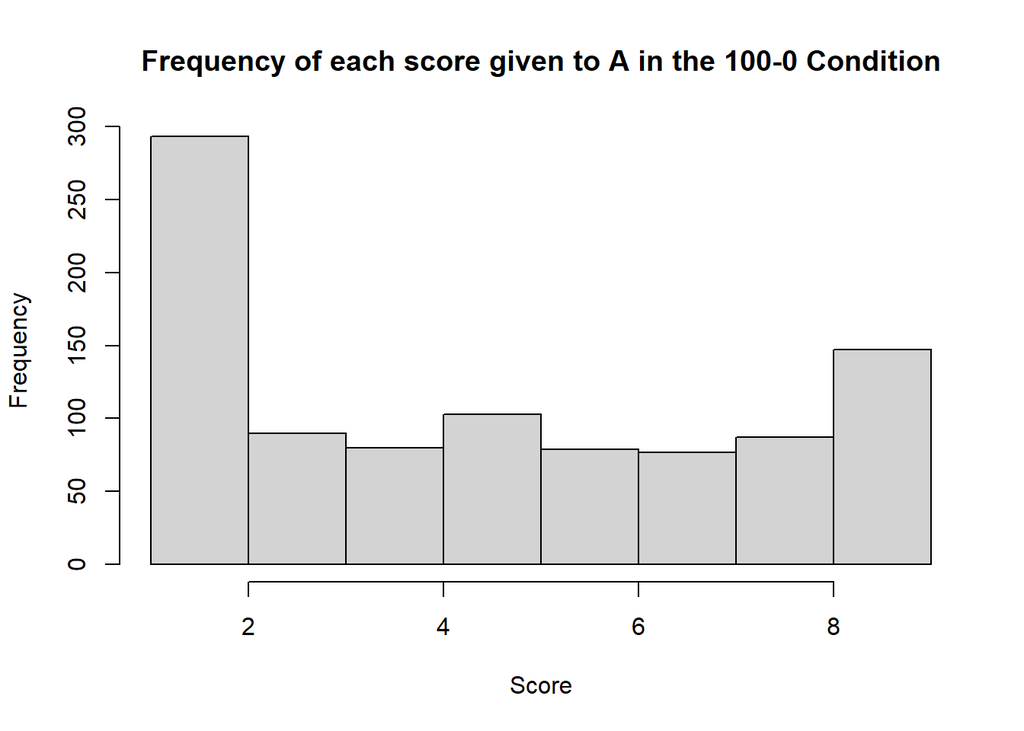

```r
hist(train$responseR1[train$Cond == "100"], breaks = 10, main = "Frequency of each score given to A in the 100-0 Condition", xlab = "Score")
```

```r
mean(train$responseR1[train$Cond == "100"], na.rm = TRUE)
```

```
## [1] 4.723849
```

This histogram shows the condition where A (responseR1) always leads to a diamond outcome. Which makes it so weird that there are so many 1’s in there

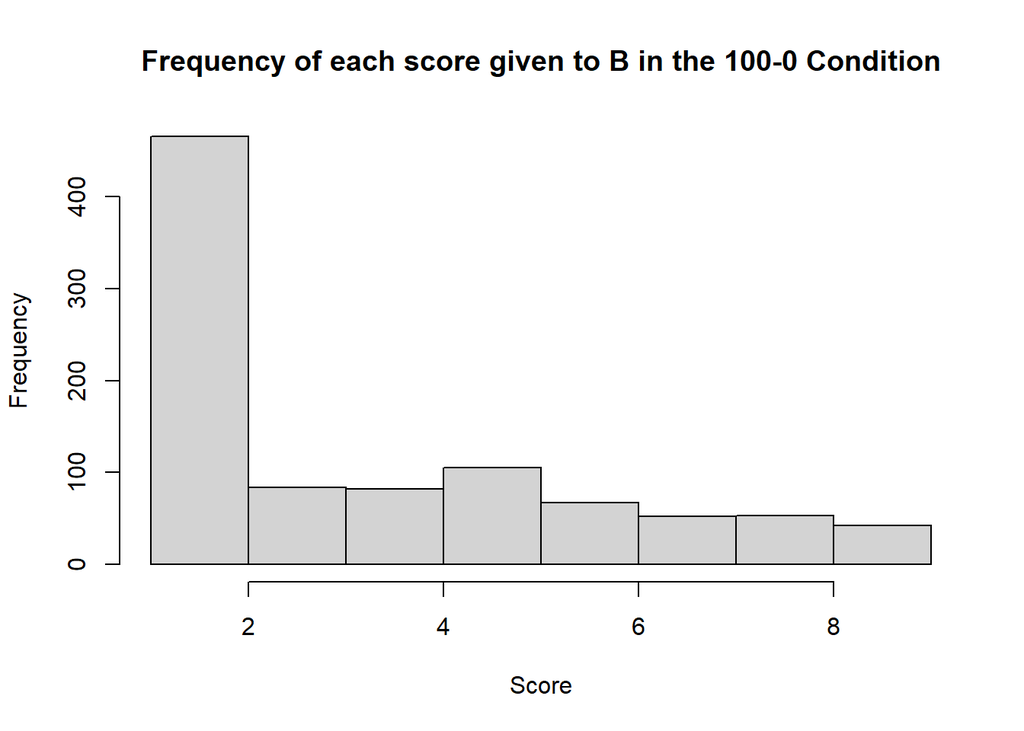

```r
hist(train$responseR2[train$Cond == "100"], breaks = 10, main = "Frequency of each score given to B in the 100-0 Condition", xlab = "Score")
```

```r
mean(train$responseR2[train$Cond == "100"], na.rm = TRUE)
```

```
## [1] 3.418947
```

This histogram shows the condition where B (responseR2) never leads to a diamond outcome. Here the amount of 1’s make more sense, and I’m glad to see that at least in comparison they differ?

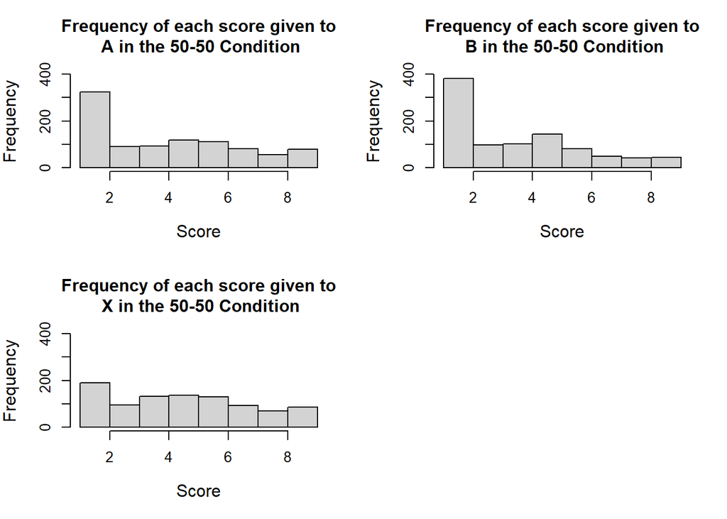

```r
par(mfrow = c(2,2))
hist(train$responseR1[train$Cond == "0"], breaks = 10, main = "Frequency of each score given to\n A in the 50-50 Condition", xlab = "Score", ylim = c(0,400), cex.lab = 1.2, cex.sub = 1.5)
hist(train$responseR2[train$Cond == "0"], breaks = 10, main = "Frequency of each score given to\n B in the 50-50 Condition", xlab = "Score", ylim = c(0,400), cex.lab = 1.2, cex.sub = 1.5)
hist(train$responseR3[train$Cond == "0"], breaks = 10, main = "Frequency of each score given to\n X in the 50-50 Condition", xlab = "Score", ylim = c(0,400), cex.lab = 1.2, cex.sub = 1.5)

par(mfrow = c(2,2))
```

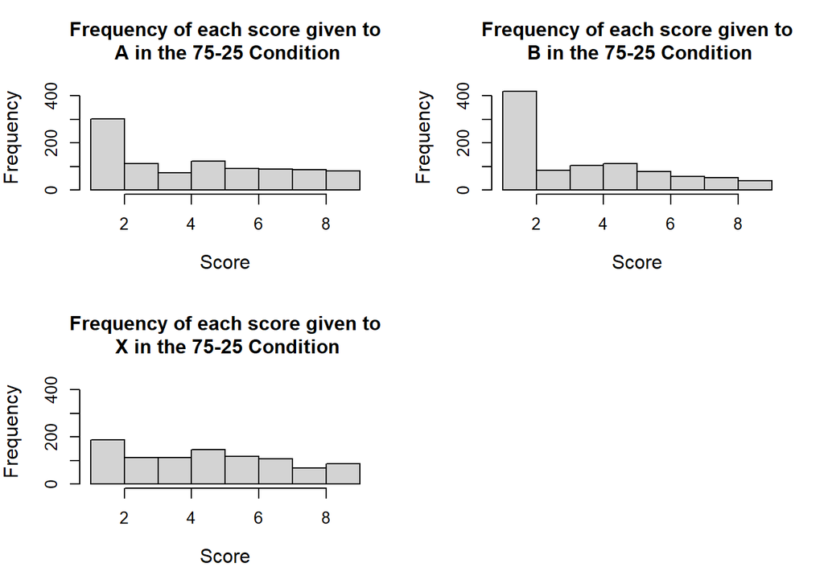

```r
hist(train$responseR1[train$Cond == "50"], breaks = 10, main = "Frequency of each score given to\n A in the 75-25 Condition", xlab = "Score", ylim = c(0,450), cex.lab = 1.2, cex.sub = 1.5)
hist(train$responseR2[train$Cond == "50"], breaks = 10, main = "Frequency of each score given to\n B in the 75-25 Condition", xlab = "Score", ylim = c(0,450), cex.lab = 1.2, cex.sub = 1.5)
hist(train$responseR3[train$Cond == "50"], breaks = 10, main = "Frequency of each score given to\n X in the 75-25 Condition", xlab = "Score", ylim = c(0,450), cex.lab = 1.2, cex.sub = 1.5)

par(mfrow = c(2,2))
```

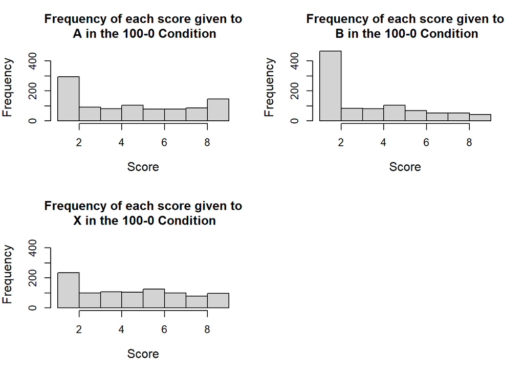

```r
hist(train$responseR1[train$Cond == "100"], breaks = 10, main = "Frequency of each score given to\n A in the 100-0 Condition", xlab = "Score", ylim = c(0,450), cex.lab = 1.2, cex.sub = 1.5)
hist(train$responseR2[train$Cond == "100"], breaks = 10, main = "Frequency of each score given to\n B in the 100-0 Condition", xlab = "Score", ylim = c(0,450), cex.lab = 1.2, cex.sub = 1.5)
hist(train$responseR3[train$Cond == "100"], breaks = 10, main = "Frequency of each score given to\n X in the 100-0 Condition", xlab = "Score", ylim = c(0,450), cex.lab = 1.2, cex.sub = 1.5)
```

## Numbers

```r
#As there are lots of 1's let's see how often people scored 1's on average for A B and X (over all conditions)

#Create a subset of data with just the 1's in there
OnesR1 <- subset(train, train$responseR1 == 1)
OnesR2 <- subset(train, train$responseR2 == 1)
OnesR3 <- subset(train, train$responseR3 == 1)
#Take the sum of these ones over participants (as we want to know how often (on average) one participant scored a 1 for A, B or X)
SumOnesR1 <- aggregate(OnesR1$responseR1, list(OnesR1$jatosStudyResultId), sum)
SumOnesR2 <- aggregate(OnesR2$responseR2, list(OnesR2$jatosStudyResultId), sum)
SumOnesR3 <- aggregate(OnesR3$responseR3, list(OnesR3$jatosStudyResultId), sum)
#then take the mean
AvgOnesR1 <- mean(SumOnesR1$x)
AvgOnesR2 <- mean(SumOnesR2$x)
AvgOnesR3 <- mean(SumOnesR3$x)
AvgOnesR1
```

```
## [1] 12.07843
```

```r
AvgOnesR2
```

```
## [1] 16.08929
```

```r
AvgOnesR3
```

```
## [1] 7.111111
```

The average amount of 1’s given to A is 12, which is 25% of all trails.  
The average amount of 1’s given to B is 16, which is 33,3% of all trials  
And the average amount of 1’s given to X is 7, which is 14,6% of all trials.  
You would expect that B is scored lower over all (as it’s the least predictive over all), and A to be scored higher over all, so have less 1’s than the rest. However what we see here is that X, the stimuli that always appears is actually scored 1 the least amount of times.

# Training phase

## Average plots

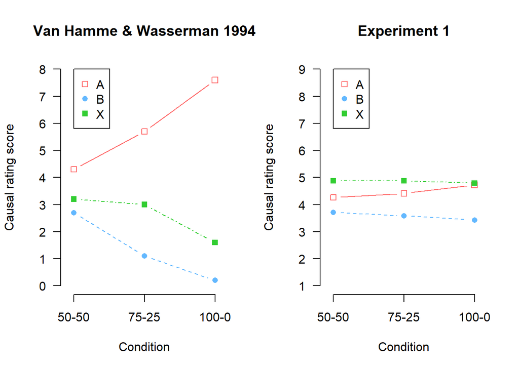

```r
par(mfrow = c(1,2))
par(las=1)
#original plot
emptyPlot(c(-5,105),c(0,8), xaxt = "none", ymark=c(0,1,2,3,4,5,6,7,8), bty='n', main = "Van Hamme & Wasserman 1994", xlab = "Condition", ylab = "Causal rating score")
A <- c(4.3,5.7,7.6)
B <- c(2.7, 1.1, 0.2)
X <- c(3.2,3,1.6)
points(c(0, 50, 100),A, pch = 0, type = "b", col = "indianred1")
points(c(0, 50, 100),B, pch =16, type = "b", lty = 2, col = "steelblue1")
points(c(0, 50, 100),X, pch =15, type = "b", lty = 4, col = "limegreen")
legend(0.05,8,legend =c("A", "B", "X"), pch = c(0,16,15), col = c("indianred1", "steelblue1", "limegreen"))
axis(1, at = c(0,50,100), labels = c("50-50", "75-25", "100-0"))

#Our experiment
emptyPlot(c(-5,105),c(1,9), xaxt = "none", ymark=c(1,2,3,4,5,6,7,8,9), bty='n', main = "Experiment 1", xlab = "Condition", ylab = "Causal rating score")
A <- c(a$A)
B <- c(a$B)
X <- c(a$X)
points(c(0, 50, 100),A, pch = 0, type = "b", col = "indianred1")
points(c(0, 50, 100),B, pch =16, type = "b", lty = 2, col = "steelblue1")
points(c(0, 50, 100),X, pch =15, type = "b", lty = 4, col = "limegreen")
legend(0.05,9,legend =c("A", "B", "X"), pch = c(0,16,15), col = c("indianred1", "steelblue1", "limegreen"))
axis(1, at = c(0,50,100), labels = c("50-50", "75-25", "100-0"))
```

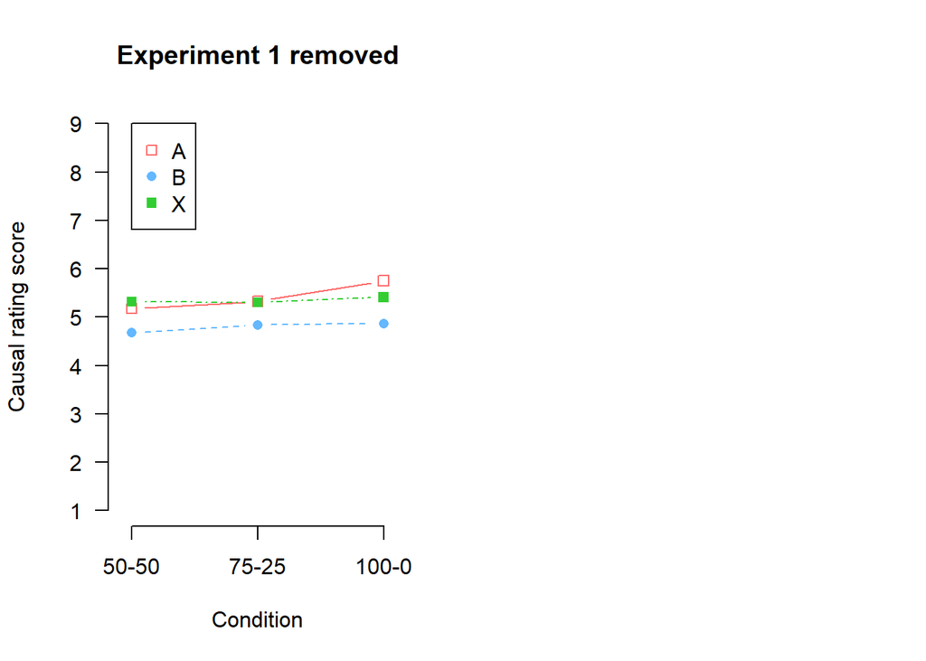

```r
#Our experiment with 1's removed
emptyPlot(c(-5,105),c(1,9), xaxt = "none", ymark=c(1,2,3,4,5,6,7,8,9), bty='n', main = "Experiment 1 removed", xlab = "Condition", ylab = "Causal rating score")
A <- c(b$A)
B <- c(b$B)
X <- c(b$X)
points(c(0, 50, 100),A, pch = 0, type = "b", col = "indianred1")
points(c(0, 50, 100),B, pch =16, type = "b", lty = 2, col = "steelblue1")
points(c(0, 50, 100),X, pch =15, type = "b", lty = 4, col = "limegreen")
legend(0.05,9,legend =c("A", "B", "X"), pch = c(0,16,15), col = c("indianred1", "steelblue1", "limegreen"))
axis(1, at = c(0,50,100), labels = c("50-50", "75-25", "100-0"))
```

### Averages but with thicker lines

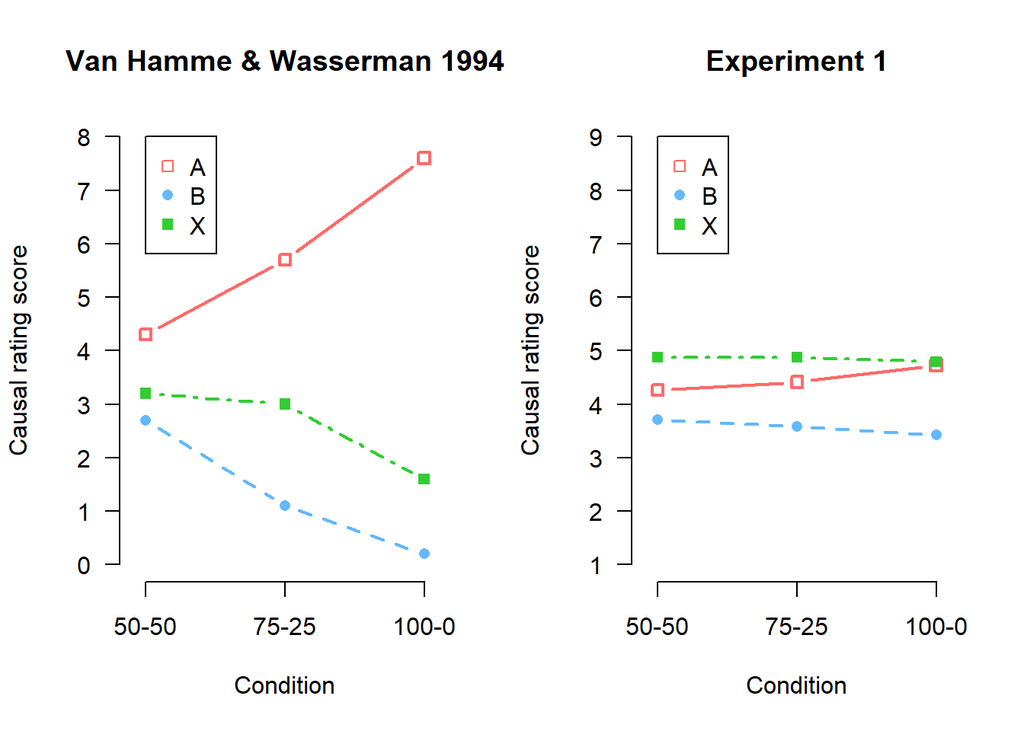

```r
par(mfrow = c(1,2))
par(las=1)
#original plot
emptyPlot(c(-5,105),c(0,8), xaxt = "none", ymark=c(0,1,2,3,4,5,6,7,8), bty='n', main = "Van Hamme & Wasserman 1994", xlab = "Condition", ylab = "Causal rating score")
A <- c(4.3,5.7,7.6)
B <- c(2.7, 1.1, 0.2)
X <- c(3.2,3,1.6)
points(c(0, 50, 100),A, pch = 0, type = "b", col = "indianred1", lwd = 2)
points(c(0, 50, 100),B, pch =16, type = "b", lty = 2, col = "steelblue1", lwd = 2)
points(c(0, 50, 100),X, pch =15, type = "b", lty = 4, col = "limegreen", lwd = 2)
legend(0.05,8,legend =c("A", "B", "X"), pch = c(0,16,15), col = c("indianred1", "steelblue1", "limegreen"))
axis(1, at = c(0,50,100), labels = c("50-50", "75-25", "100-0"))

#Our experiment
emptyPlot(c(-5,105),c(1,9), xaxt = "none", ymark=c(1,2,3,4,5,6,7,8,9), bty='n', main = "Experiment 1", xlab = "Condition", ylab = "Causal rating score")
A <- c(a$A)
B <- c(a$B)
X <- c(a$X)
points(c(0, 50, 100),A, pch = 0, type = "b", col = "indianred1", lwd = 2)
points(c(0, 50, 100),B, pch =16, type = "b", lty = 2, col = "steelblue1", lwd = 2)
points(c(0, 50, 100),X, pch =15, type = "b", lty = 4, col = "limegreen", lwd = 2)
legend(0.05,9,legend =c("A", "B", "X"), pch = c(0,16,15), col = c("indianred1", "steelblue1", "limegreen"))
axis(1, at = c(0,50,100), labels = c("50-50", "75-25", "100-0"))
```

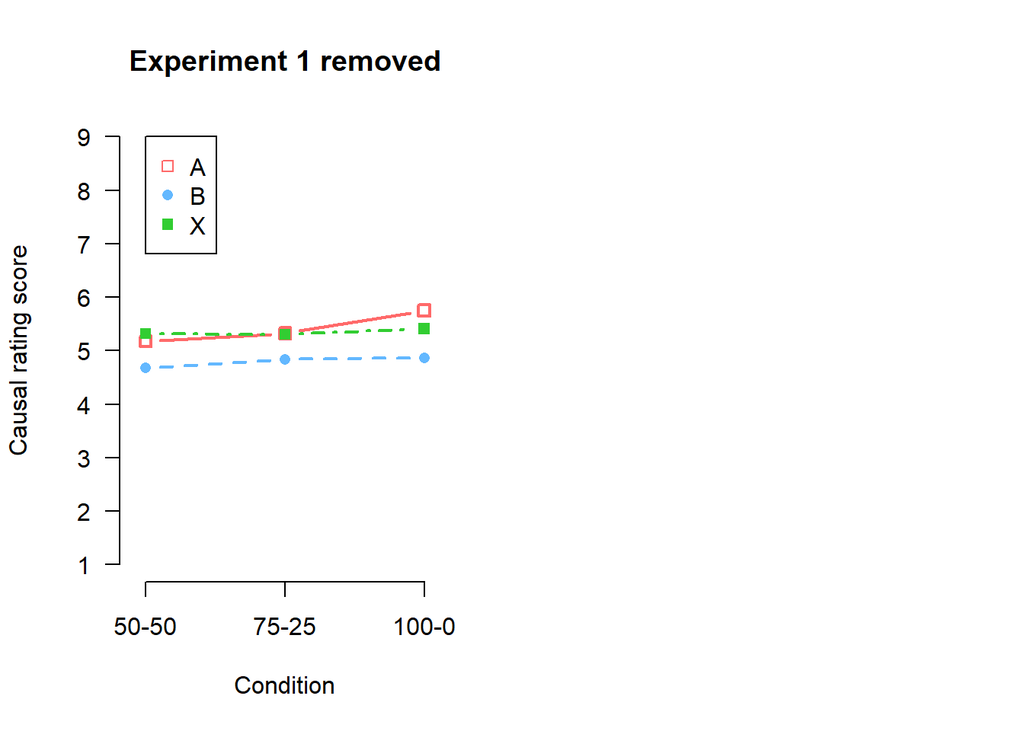

```r
#Our experiment with 1's removed
emptyPlot(c(-5,105),c(1,9), xaxt = "none", ymark=c(1,2,3,4,5,6,7,8,9), bty='n', main = "Experiment 1 removed", xlab = "Condition", ylab = "Causal rating score")
A <- c(b$A)
B <- c(b$B)
X <- c(b$X)
points(c(0, 50, 100),A, pch = 0, type = "b", col = "indianred1", lwd = 2)
points(c(0, 50, 100),B, pch =16, type = "b", lty = 2, col = "steelblue1", lwd = 2)
points(c(0, 50, 100),X, pch =15, type = "b", lty = 4, col = "limegreen", lwd = 2)
legend(0.05,9,legend =c("A", "B", "X"), pch = c(0,16,15), col = c("indianred1", "steelblue1", "limegreen"))
axis(1, at = c(0,50,100), labels = c("50-50", "75-25", "100-0"))
```

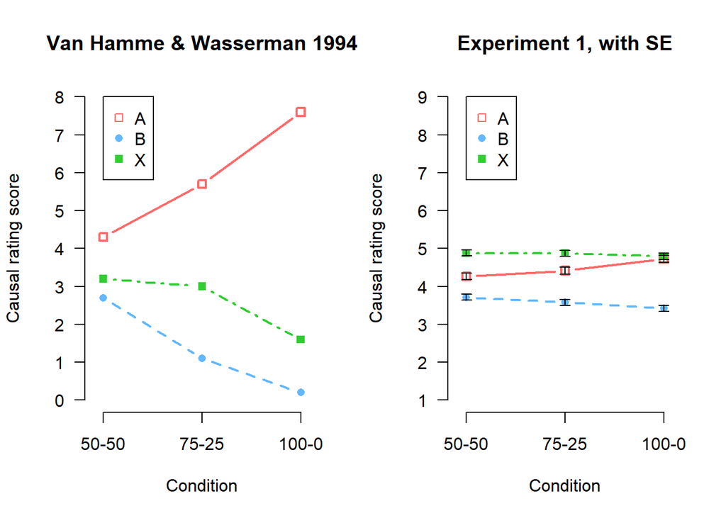

```r
par(mfrow = c(1,2))
par(las=1)
#original plot
emptyPlot(c(-5,105),c(0,8), xaxt = "none", ymark=c(0,1,2,3,4,5,6,7,8), bty='n', main = "Van Hamme & Wasserman 1994", xlab = "Condition", ylab = "Causal rating score")
A <- c(4.3,5.7,7.6)
B <- c(2.7, 1.1, 0.2)
X <- c(3.2,3,1.6)
points(c(0, 50, 100),A, pch = 0, type = "b", col = "indianred1", lwd = 2)
points(c(0, 50, 100),B, pch =16, type = "b", lty = 2, col = "steelblue1", lwd = 2)
points(c(0, 50, 100),X, pch =15, type = "b", lty = 4, col = "limegreen", lwd = 2)
legend(0.05,8,legend =c("A", "B", "X"), pch = c(0,16,15), col = c("indianred1", "steelblue1", "limegreen"))
axis(1, at = c(0,50,100), labels = c("50-50", "75-25", "100-0"))

#Our experiment
emptyPlot(c(-5,105),c(1,9), xaxt = "none", ymark=c(1,2,3,4,5,6,7,8,9), bty='n', main = "Experiment 1, with SE", xlab = "Condition", ylab = "Causal rating score")
A <- c(a$A)
B <- c(a$B)
X <- c(a$X)
points(c(0, 50, 100),A, pch = 0, type = "b", col = "indianred1", lwd = 2)
points(c(0, 50, 100),B, pch =16, type = "b", lty = 2, col = "steelblue1", lwd = 2)
points(c(0, 50, 100),X, pch =15, type = "b", lty = 4, col = "limegreen", lwd = 2)
legend(0.05,9,legend =c("A", "B", "X"), pch = c(0,16,15), col = c("indianred1", "steelblue1", "limegreen"))
errorbars(x= c(0,50,100), y = a$A, top = SECondA, bottom = SECondA, add = TRUE, length = 0.05)
errorbars(x= c(0,50,100), y = a$B, top = SECondB, bottom = SECondB, add = TRUE, length = 0.05)
errorbars(x= c(0,50,100), y = a$X, top = SECondX, bottom = SECondX, add = TRUE, length = 0.05)
axis(1, at = c(0,50,100), labels = c("50-50", "75-25", "100-0"))
```

## Condition 50-50

### Cond 000

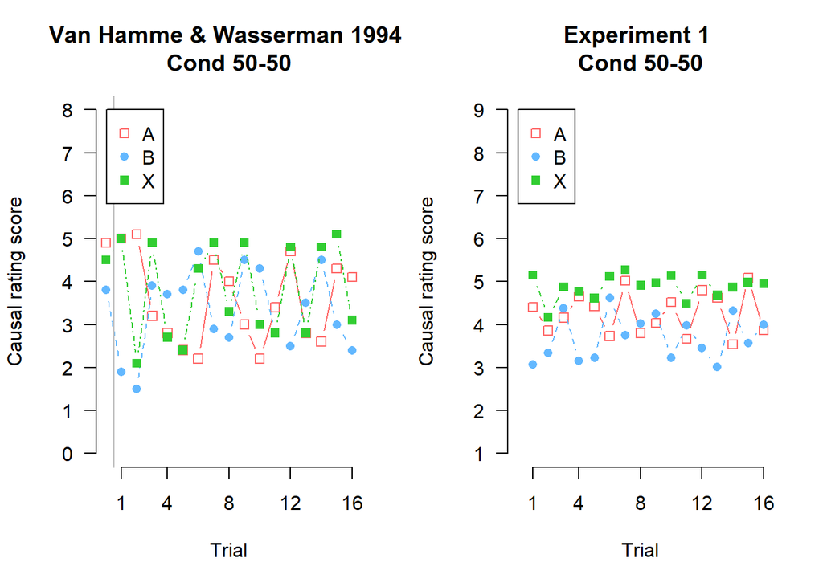

```r
par(mfrow = c(1,2))
par(las=1)
#original plot
emptyPlot(c(0,16),c(0,8), xmark = c(1,4,8,12,16), ymark=c(0,1,2,3,4,5,6,7,8), bty='n', main = "Van Hamme & Wasserman 1994 \nCond 50-50", xlab = "Trial", ylab = "Causal rating score")
A <- c(4.9, 5, 5.1, 3.2, 2.8, 2.4, 2.2, 4.5, 4, 3, 2.2, 3.4, 4.7, 2.8, 2.6, 4.3, 4.1)
B <- c(3.8, 1.9, 1.5, 3.9, 3.7, 3.8, 4.7, 2.9, 2.7, 4.5, 4.3, 2.8, 2.5, 3.5, 4.5, 3, 2.4)
X <- c(4.5, 5, 2.1, 4.9, 2.7, 2.4, 4.3, 4.9, 3.3, 4.9, 3, 2.8, 4.8,2.8, 4.8, 5.1, 3.1)
points(c(0:16),A, pch = 0, type = "b", col = "indianred1")
points(c(0:16),B, pch =16, type = "b", lty = 2, col = "steelblue1")
points(c(0:16),X, pch =15, type = "b", lty = 4, col = "limegreen")
abline(v=0.5, col="grey", lty = 1)
legend(0.05,8,legend =c("A", "B", "X"), pch = c(0,16,15), col = c("indianred1", "steelblue1", "limegreen"))

emptyPlot(c(0,16),c(1,9), xmark = c(1,4,8,12,16), ymark=c(1,2,3,4,5,6,7,8, 9), bty='n', main = "Experiment 1 \nCond 50-50", xlab = "Trial", ylab = "Causal rating score")
A <- Cond000$A
B <- Cond000$B
X <- Cond000$X
points(c(1:16),A, pch = 0, type = "b", col = "indianred1")
points(c(1:16),B, pch =16, type = "b", lty = 2, col = "steelblue1")
points(c(1:16),X, pch =15, type = "b", lty = 4, col = "limegreen")
legend(0.05,9,legend =c("A", "B", "X"), pch = c(0,16,15), col = c("indianred1", "steelblue1", "limegreen"))
```

### Cond 000 Thick lines

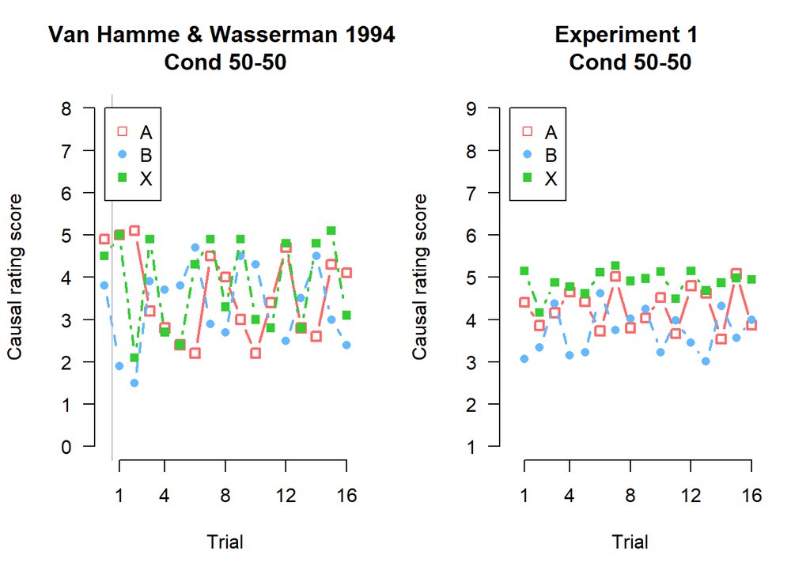

```r
par(mfrow = c(1,2))
par(las=1)
#original plot
emptyPlot(c(0,16),c(0,8), xmark = c(1,4,8,12,16), ymark=c(0,1,2,3,4,5,6,7,8), bty='n', main = "Van Hamme & Wasserman 1994 \nCond 50-50", xlab = "Trial", ylab = "Causal rating score")
A <- c(4.9, 5, 5.1, 3.2, 2.8, 2.4, 2.2, 4.5, 4, 3, 2.2, 3.4, 4.7, 2.8, 2.6, 4.3, 4.1)
B <- c(3.8, 1.9, 1.5, 3.9, 3.7, 3.8, 4.7, 2.9, 2.7, 4.5, 4.3, 2.8, 2.5, 3.5, 4.5, 3, 2.4)
X <- c(4.5, 5, 2.1, 4.9, 2.7, 2.4, 4.3, 4.9, 3.3, 4.9, 3, 2.8, 4.8,2.8, 4.8, 5.1, 3.1)
points(c(0:16),A, pch = 0, type = "b", col = "indianred1", lwd = 2)
points(c(0:16),B, pch =16, type = "b", lty = 2, col = "steelblue1", lwd = 2)
points(c(0:16),X, pch =15, type = "b", lty = 4, col = "limegreen", lwd = 2)
abline(v=0.5, col="grey", lty = 1)
legend(0.05,8,legend =c("A", "B", "X"), pch = c(0,16,15), col = c("indianred1", "steelblue1", "limegreen"))

emptyPlot(c(0,16),c(1,9), xmark = c(1,4,8,12,16), ymark=c(1,2,3,4,5,6,7,8, 9), bty='n', main = "Experiment 1 \nCond 50-50", xlab = "Trial", ylab = "Causal rating score")
A <- Cond000$A
B <- Cond000$B
X <- Cond000$X
points(c(1:16),A, pch = 0, type = "b", col = "indianred1", lwd = 2)
points(c(1:16),B, pch =16, type = "b", lty = 2, col = "steelblue1" , lwd = 2)
points(c(1:16),X, pch =15, type = "b", lty = 4, col = "limegreen", lwd = 2)
legend(0.05,9,legend =c("A", "B", "X"), pch = c(0,16,15), col = c("indianred1", "steelblue1", "limegreen"))
```

### Cond 000 SE bars

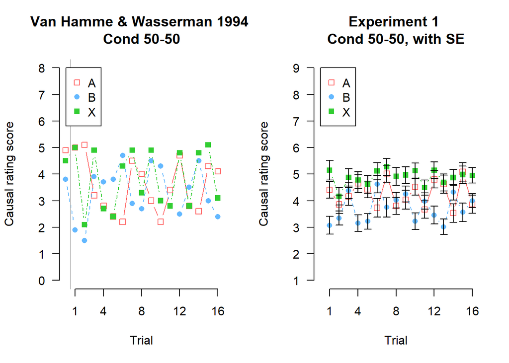

```r
par(mfrow = c(1,2))
par(las=1)
#original plot
emptyPlot(c(0,16),c(0,8), xmark = c(1,4,8,12,16), ymark=c(0,1,2,3,4,5,6,7,8), bty='n', main = "Van Hamme & Wasserman 1994 \nCond 50-50", xlab = "Trial", ylab = "Causal rating score")
A <- c(4.9, 5, 5.1, 3.2, 2.8, 2.4, 2.2, 4.5, 4, 3, 2.2, 3.4, 4.7, 2.8, 2.6, 4.3, 4.1)
B <- c(3.8, 1.9, 1.5, 3.9, 3.7, 3.8, 4.7, 2.9, 2.7, 4.5, 4.3, 2.8, 2.5, 3.5, 4.5, 3, 2.4)
X <- c(4.5, 5, 2.1, 4.9, 2.7, 2.4, 4.3, 4.9, 3.3, 4.9, 3, 2.8, 4.8,2.8, 4.8, 5.1, 3.1)
points(c(0:16),A, pch = 0, type = "b", col = "indianred1")
points(c(0:16),B, pch =16, type = "b", lty = 2, col = "steelblue1")
points(c(0:16),X, pch =15, type = "b", lty = 4, col = "limegreen")
abline(v=0.5, col="grey", lty = 1)
legend(0.05,8,legend =c("A", "B", "X"), pch = c(0,16,15), col = c("indianred1", "steelblue1", "limegreen"))

emptyPlot(c(0,16),c(1,9), xmark = c(1,4,8,12,16), ymark=c(1,2,3,4,5,6,7,8, 9), bty='n', main = "Experiment 1 \nCond 50-50, with SE", xlab = "Trial", ylab = "Causal rating score")
A <- Cond000$A
B <- Cond000$B
X <- Cond000$X
points(c(1:16),A, pch = 0, type = "b", col = "indianred1")
points(c(1:16),B, pch =16, type = "b", lty = 2, col = "steelblue1")
points(c(1:16),X, pch =15, type = "b", lty = 4, col = "limegreen")
errorbars(x= c(1:16), y = Cond000$A, top = SETrials000A, bottom = SETrials000A, add = TRUE, length = 0.05)
errorbars(x= c(1:16), y = Cond000$B, top = SETrials000B, bottom = SETrials000B, add = TRUE, length = 0.05)
errorbars(x= c(1:16), y = Cond000$X, top = SETrials000X, bottom = SETrials000X, add = TRUE, length = 0.05)
legend(0.05,9,legend =c("A", "B", "X"), pch = c(0,16,15), col = c("indianred1", "steelblue1", "limegreen"))
```

## Condition 75-25

### Cond 050

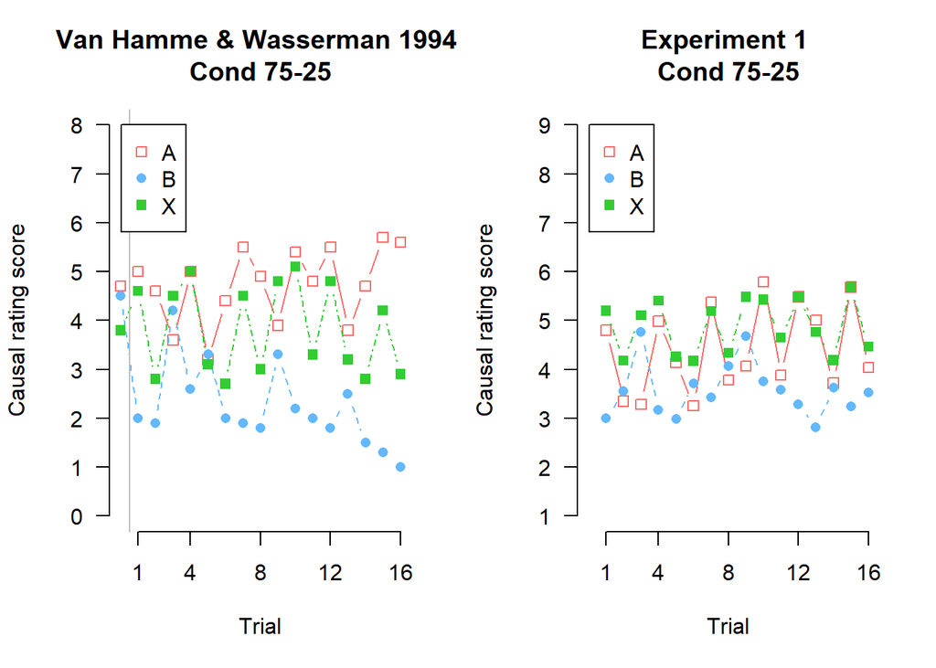

```r
par(mfrow = c(1,2))
par(las=1)
#original plot
emptyPlot(c(0,16),c(0,8), xmark = c(1,4,8,12,16), ymark=c(0,1,2,3,4,5,6,7,8), bty='n', main = "Van Hamme & Wasserman 1994 \nCond 75-25", xlab = "Trial", ylab = "Causal rating score")
A <- c(4.7,5,4.6,3.6,5,3.2,4.4,5.5,4.9,3.9,5.4,4.8,5.5,3.8,4.7,5.7,5.6)
B <- c(4.5,2,1.9,4.2,2.6,3.3,2,1.9,1.8,3.3,2.2,2,1.8,2.5,1.5,1.3,1)
X <- c(3.8,4.6,2.8,4.5,5,3.1,2.7,4.5,3,4.8,5.1,3.3,4.8,3.2,2.8,4.2,2.9)
points(c(0:16),A, pch = 0, type = "b", col = "indianred1")
points(c(0:16),B, pch =16, type = "b", lty = 2, col = "steelblue1")
points(c(0:16),X, pch =15, type = "b", lty = 4, col = "limegreen")
abline(v=0.5, col="grey", lty = 1)
legend(0.05,8,legend =c("A", "B", "X"), pch = c(0,16,15), col = c("indianred1", "steelblue1", "limegreen"))


emptyPlot(c(0,16),c(1,9), xmark = c(1,4,8,12,16), ymark=c(1,2,3,4,5,6,7,8, 9), bty='n', main = "Experiment 1 \nCond 75-25", xlab = "Trial", ylab = "Causal rating score")
A <- Cond050$A
B <- Cond050$B
X <- Cond050$X
points(c(1:16),A, pch = 0, type = "b", col = "indianred1")
points(c(1:16),B, pch =16, type = "b", lty = 2, col = "steelblue1")
points(c(1:16),X, pch =15, type = "b", lty = 4, col = "limegreen")
legend(0.05,9,legend =c("A", "B", "X"), pch = c(0,16,15), col = c("indianred1", "steelblue1", "limegreen"))
```

### Cond 050 Thicker lines

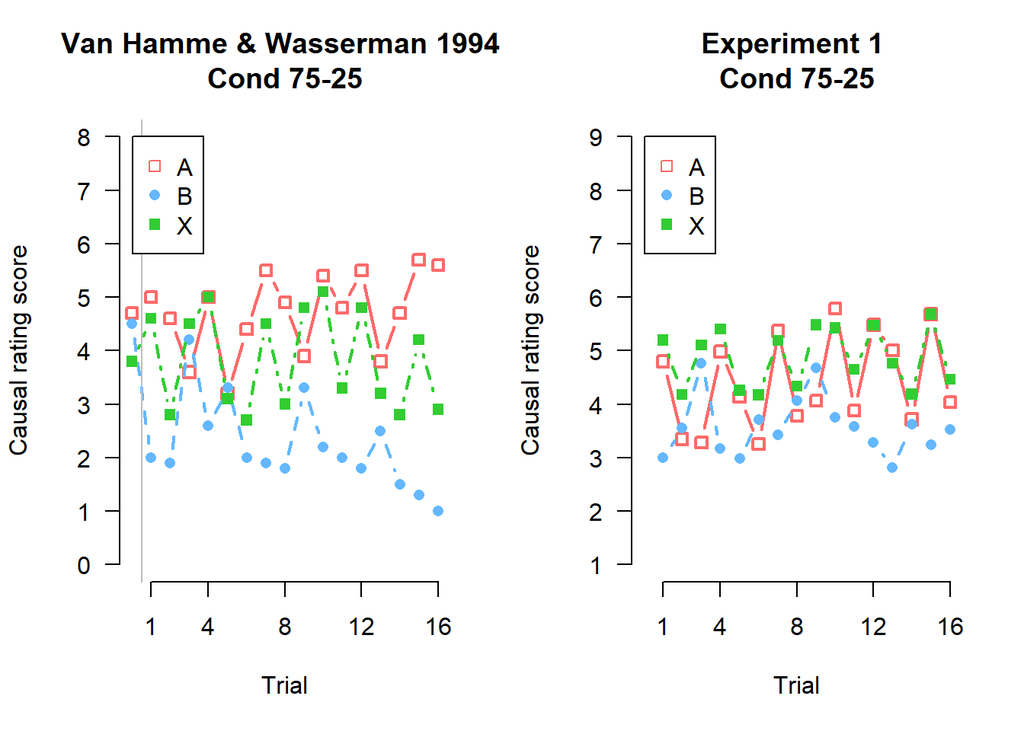

```r
par(mfrow = c(1,2))
par(las=1)
#original plot
emptyPlot(c(0,16),c(0,8), xmark = c(1,4,8,12,16), ymark=c(0,1,2,3,4,5,6,7,8), bty='n', main = "Van Hamme & Wasserman 1994 \nCond 75-25", xlab = "Trial", ylab = "Causal rating score")
A <- c(4.7,5,4.6,3.6,5,3.2,4.4,5.5,4.9,3.9,5.4,4.8,5.5,3.8,4.7,5.7,5.6)
B <- c(4.5,2,1.9,4.2,2.6,3.3,2,1.9,1.8,3.3,2.2,2,1.8,2.5,1.5,1.3,1)
X <- c(3.8,4.6,2.8,4.5,5,3.1,2.7,4.5,3,4.8,5.1,3.3,4.8,3.2,2.8,4.2,2.9)
points(c(0:16),A, pch = 0, type = "b", col = "indianred1", lwd = 2)
points(c(0:16),B, pch =16, type = "b", lty = 2, col = "steelblue1", lwd = 2)
points(c(0:16),X, pch =15, type = "b", lty = 4, col = "limegreen", lwd = 2)
abline(v=0.5, col="grey", lty = 1)
legend(0.05,8,legend =c("A", "B", "X"), pch = c(0,16,15), col = c("indianred1", "steelblue1", "limegreen"))


emptyPlot(c(0,16),c(1,9), xmark = c(1,4,8,12,16), ymark=c(1,2,3,4,5,6,7,8, 9), bty='n', main = "Experiment 1 \nCond 75-25", xlab = "Trial", ylab = "Causal rating score")
A <- Cond050$A
B <- Cond050$B
X <- Cond050$X
points(c(1:16),A, pch = 0, type = "b", col = "indianred1", lwd = 2)
points(c(1:16),B, pch =16, type = "b", lty = 2, col = "steelblue1", lwd = 2)
points(c(1:16),X, pch =15, type = "b", lty = 4, col = "limegreen", lwd = 2)
legend(0.05,9,legend =c("A", "B", "X"), pch = c(0,16,15), col = c("indianred1", "steelblue1", "limegreen"))
```

### Cond 050 SE bars

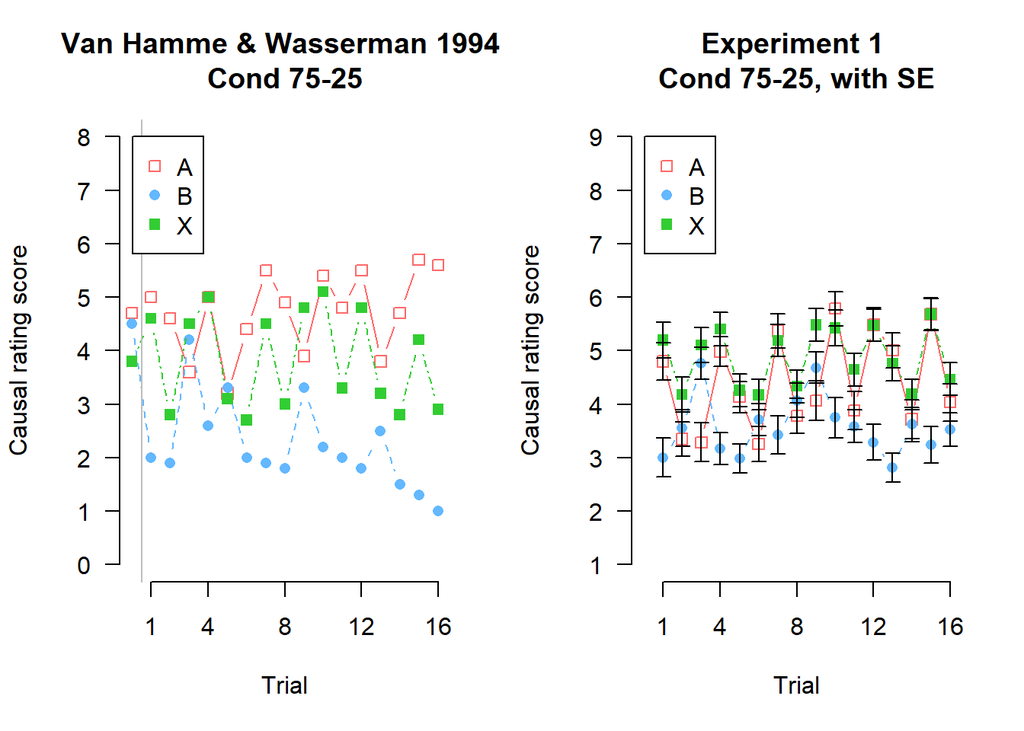

```r
par(mfrow = c(1,2))
par(las=1)
#original plot
emptyPlot(c(0,16),c(0,8), xmark = c(1,4,8,12,16), ymark=c(0,1,2,3,4,5,6,7,8), bty='n', main = "Van Hamme & Wasserman 1994 \nCond 75-25", xlab = "Trial", ylab = "Causal rating score")
A <- c(4.7,5,4.6,3.6,5,3.2,4.4,5.5,4.9,3.9,5.4,4.8,5.5,3.8,4.7,5.7,5.6)
B <- c(4.5,2,1.9,4.2,2.6,3.3,2,1.9,1.8,3.3,2.2,2,1.8,2.5,1.5,1.3,1)
X <- c(3.8,4.6,2.8,4.5,5,3.1,2.7,4.5,3,4.8,5.1,3.3,4.8,3.2,2.8,4.2,2.9)
points(c(0:16),A, pch = 0, type = "b", col = "indianred1")
points(c(0:16),B, pch =16, type = "b", lty = 2, col = "steelblue1")
points(c(0:16),X, pch =15, type = "b", lty = 4, col = "limegreen")
abline(v=0.5, col="grey", lty = 1)
legend(0.05,8,legend =c("A", "B", "X"), pch = c(0,16,15), col = c("indianred1", "steelblue1", "limegreen"))


emptyPlot(c(0,16),c(1,9), xmark = c(1,4,8,12,16), ymark=c(1,2,3,4,5,6,7,8, 9), bty='n', main = "Experiment 1 \nCond 75-25, with SE", xlab = "Trial", ylab = "Causal rating score")
A <- Cond050$A
B <- Cond050$B
X <- Cond050$X
points(c(1:16),A, pch = 0, type = "b", col = "indianred1")
points(c(1:16),B, pch =16, type = "b", lty = 2, col = "steelblue1")
points(c(1:16),X, pch =15, type = "b", lty = 4, col = "limegreen")
errorbars(x= c(1:16), y = Cond050$A, top = SETrials050A, bottom = SETrials050A, add = TRUE, length = 0.05)
errorbars(x= c(1:16), y = Cond050$B, top = SETrials050B, bottom = SETrials050B, add = TRUE, length = 0.05)
errorbars(x= c(1:16), y = Cond050$X, top = SETrials050X, bottom = SETrials050X, add = TRUE, length = 0.05)
legend(0.05,9,legend =c("A", "B", "X"), pch = c(0,16,15), col = c("indianred1", "steelblue1", "limegreen"))
```

## Condition 100-0

### Cond 100

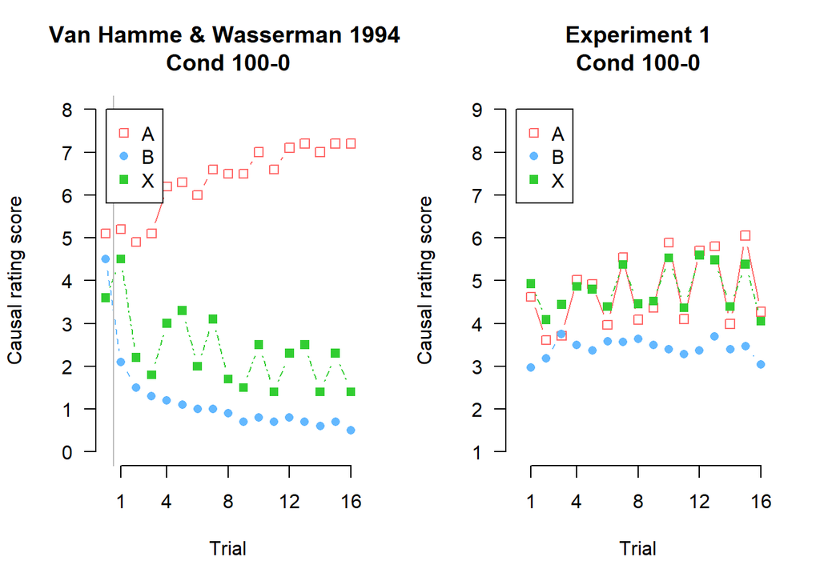

```r
par(mfrow = c(1,2))
par(las=1)
#original plot
emptyPlot(c(0,16),c(0,8), xmark = c(1,4,8,12,16), ymark=c(0,1,2,3,4,5,6,7,8), bty='n', main = "Van Hamme & Wasserman 1994 \nCond 100-0", xlab = "Trial", ylab = "Causal rating score")
A <- c(5.1,5.2,4.9,5.1,6.2,6.3,6,6.6,6.5,6.5,7,6.6,7.1,7.2,7,7.2,7.2)
B <- c(4.5,2.1,1.5,1.3,1.2,1.1,1,1,0.9,0.7,0.8,0.7,0.8,0.7,0.6,0.7,0.5)
X <- c(3.6,4.5,2.2,1.8,3,3.3,2,3.1,1.7,1.5,2.5,1.4,2.3,2.5,1.4,2.3,1.4)
points(c(0:16),A, pch = 0, type = "b", col = "indianred1")
points(c(0:16),B, pch =16, type = "b", lty = 2, col = "steelblue1")
points(c(0:16),X, pch =15, type = "b", lty = 4, col = "limegreen")
abline(v=0.5, col="grey", lty = 1)
legend(0.05,8,legend =c("A", "B", "X"), pch = c(0,16,15), col = c("indianred1", "steelblue1", "limegreen"))

emptyPlot(c(0,16),c(1,9), xmark = c(1,4,8,12,16), ymark=c(1,2,3,4,5,6,7,8, 9), bty='n', main = "Experiment 1\nCond 100-0", xlab = "Trial", ylab = "Causal rating score")
A <- Cond100$A
B <- Cond100$B
X <- Cond100$X
points(c(1:16),A, pch = 0, type = "b", col = "indianred1")
points(c(1:16),B, pch =16, type = "b", lty = 2, col = "steelblue1")
points(c(1:16),X, pch =15, type = "b", lty = 4, col = "limegreen")
legend(0.05,9,legend =c("A", "B", "X"), pch = c(0,16,15), col = c("indianred1", "steelblue1", "limegreen"))
```

### Cond 100 Thicker lines

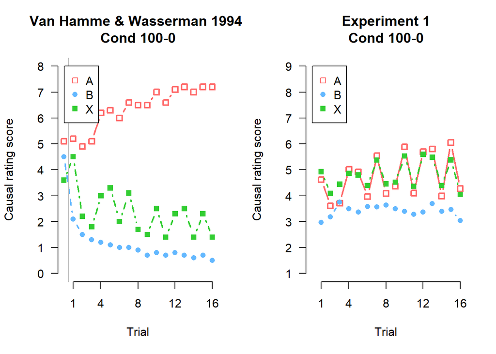

```r
par(mfrow = c(1,2))
par(las=1)
#original plot
emptyPlot(c(0,16),c(0,8), xmark = c(1,4,8,12,16), ymark=c(0,1,2,3,4,5,6,7,8), bty='n', main = "Van Hamme & Wasserman 1994 \nCond 100-0", xlab = "Trial", ylab = "Causal rating score")
A <- c(5.1,5.2,4.9,5.1,6.2,6.3,6,6.6,6.5,6.5,7,6.6,7.1,7.2,7,7.2,7.2)
B <- c(4.5,2.1,1.5,1.3,1.2,1.1,1,1,0.9,0.7,0.8,0.7,0.8,0.7,0.6,0.7,0.5)
X <- c(3.6,4.5,2.2,1.8,3,3.3,2,3.1,1.7,1.5,2.5,1.4,2.3,2.5,1.4,2.3,1.4)
points(c(0:16),A, pch = 0, type = "b", col = "indianred1", lwd = 2)
points(c(0:16),B, pch =16, type = "b", lty = 2, col = "steelblue1", lwd = 2)
points(c(0:16),X, pch =15, type = "b", lty = 4, col = "limegreen", lwd = 2)
abline(v=0.5, col="grey", lty = 1)
legend(0.05,8,legend =c("A", "B", "X"), pch = c(0,16,15), col = c("indianred1", "steelblue1", "limegreen"))

emptyPlot(c(0,16),c(1,9), xmark = c(1,4,8,12,16), ymark=c(1,2,3,4,5,6,7,8, 9), bty='n', main = "Experiment 1\nCond 100-0", xlab = "Trial", ylab = "Causal rating score")
A <- Cond100$A
B <- Cond100$B
X <- Cond100$X
points(c(1:16),A, pch = 0, type = "b", col = "indianred1", lwd = 2)
points(c(1:16),B, pch =16, type = "b", lty = 2, col = "steelblue1", lwd = 2)
points(c(1:16),X, pch =15, type = "b", lty = 4, col = "limegreen", lwd = 2)
legend(0.05,9,legend =c("A", "B", "X"), pch = c(0,16,15), col = c("indianred1", "steelblue1", "limegreen"))
```

### Cond 100 SE

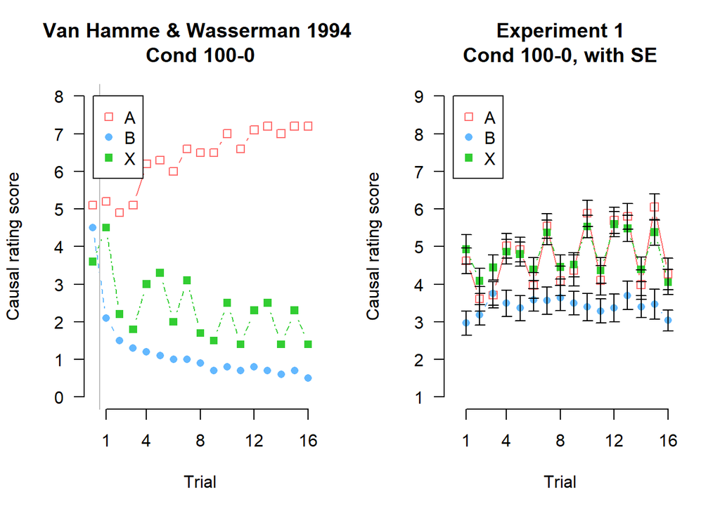

```r
par(mfrow = c(1,2))
par(las=1)
#original plot
emptyPlot(c(0,16),c(0,8), xmark = c(1,4,8,12,16), ymark=c(0,1,2,3,4,5,6,7,8), bty='n', main = "Van Hamme & Wasserman 1994 \nCond 100-0", xlab = "Trial", ylab = "Causal rating score")
A <- c(5.1,5.2,4.9,5.1,6.2,6.3,6,6.6,6.5,6.5,7,6.6,7.1,7.2,7,7.2,7.2)
B <- c(4.5,2.1,1.5,1.3,1.2,1.1,1,1,0.9,0.7,0.8,0.7,0.8,0.7,0.6,0.7,0.5)
X <- c(3.6,4.5,2.2,1.8,3,3.3,2,3.1,1.7,1.5,2.5,1.4,2.3,2.5,1.4,2.3,1.4)
points(c(0:16),A, pch = 0, type = "b", col = "indianred1")
points(c(0:16),B, pch =16, type = "b", lty = 2, col = "steelblue1")
points(c(0:16),X, pch =15, type = "b", lty = 4, col = "limegreen")
abline(v=0.5, col="grey", lty = 1)
legend(0.05,8,legend =c("A", "B", "X"), pch = c(0,16,15), col = c("indianred1", "steelblue1", "limegreen"))

emptyPlot(c(0,16),c(1,9), xmark = c(1,4,8,12,16), ymark=c(1,2,3,4,5,6,7,8, 9), bty='n', main = "Experiment 1\nCond 100-0, with SE", xlab = "Trial", ylab = "Causal rating score")
A <- Cond100$A
B <- Cond100$B
X <- Cond100$X
points(c(1:16),A, pch = 0, type = "b", col = "indianred1")
points(c(1:16),B, pch =16, type = "b", lty = 2, col = "steelblue1")
points(c(1:16),X, pch =15, type = "b", lty = 4, col = "limegreen")
errorbars(x= c(1:16), y = Cond100$A, top = SETrials100A, bottom = SETrials100A, add = TRUE, length = 0.05)
errorbars(x= c(1:16), y = Cond100$B, top = SETrials100B, bottom = SETrials100B, add = TRUE, length = 0.05)
errorbars(x= c(1:16), y = Cond100$X, top = SETrials100X, bottom = SETrials100X, add = TRUE, length = 0.05)
legend(0.05,9,legend =c("A", "B", "X"), pch = c(0,16,15), col = c("indianred1", "steelblue1", "limegreen"))
```

## Plotting participants over the whole experiment

```r
#randomly pick 5 participants (and keep those same participants, so the random is only for picking them the first time)
#sample(unique(dat$prolific_id), 5, replace = TRUE)
#gives us:
#5ed558bb9c43bc0d1ad52987 5edd1c649e50c2a126f60b17 5fc6b25adb97a63895d5435f 5f77909866be1b30356654c1 6004121207eaeb51c23d8b93

#so I'll plot those five people
P1 <- subset(train, train$prolific_id == "5ed558bb9c43bc0d1ad52987")
P2 <- subset(train, train$prolific_id == "5edd1c649e50c2a126f60b17")
P3 <- subset(train, train$prolific_id == "5fc6b25adb97a63895d5435f")
P4 <- subset(train, train$prolific_id == "5f77909866be1b30356654c1")
P5 <- subset(train, train$prolific_id == "6004121207eaeb51c23d8b93")
```

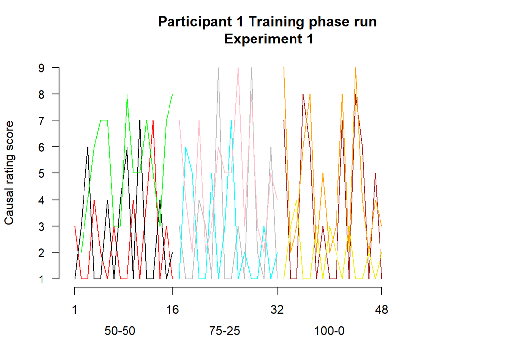

```r
#p1 had Cond 0, 50, 100
par(mfrow = c(1,1))
par(las = 1)
emptyPlot(c(1,60), c(1,9), xmark = c(1,16,32,48), ymark= c(1,2,3,4,5,6,7,8,9), bty = 'n', main = "Participant 1 Training phase run\n Experiment 1", xlab = "", ylab = "Causal rating score")
points(c(1:16), P1$responseR1[P1$blockNr == "Block1"], type = 'l', col = "red", lty = 1, lwd = 1)
points(c(1:16), P1$responseR2[P1$blockNr == "Block1"], type = 'l', col = "black", lty = 1, lwd = 1)
points(c(1:16), P1$responseR3[P1$blockNr == "Block1"], type = 'l', col = "green", lty = 1, lwd = 1)
points(c(17:32), P1$responseR1[P1$blockNr == "Block2"], type = 'l', col = "grey", lty = 1, lwd = 1)
points(c(17:32), P1$responseR2[P1$blockNr == "Block2"], type = 'l', col = "cyan", lty = 1, lwd = 1)
points(c(17:32), P1$responseR3[P1$blockNr == "Block2"], type = 'l', col = "pink", lty = 1, lwd = 1)
points(c(33:48), P1$responseR1[P1$blockNr == "Block3"], type = 'l', col = "brown", lty = 1, lwd = 1)
points(c(33:48), P1$responseR2[P1$blockNr == "Block3"], type = 'l', col = "yellow2", lty = 1, lwd = 1)
points(c(33:48), P1$responseR3[P1$blockNr == "Block3"], type = 'l', col = "orange", lty = 1, lwd = 1)
mtext("50-50", side = 1, at = 8, line = 2.5)
mtext("75-25", side = 1, at = 24, line = 2.5)
mtext("100-0", side = 1, at = 40, line = 2.5)
```

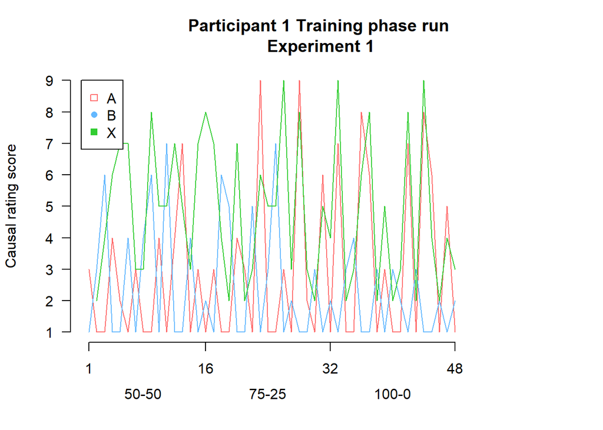

```r
#still P1
par(mfrow = c(1,1))
par(las = 1)
emptyPlot(c(1,60), c(1,9), xmark = c(1,16,32,48), ymark= c(1,2,3,4,5,6,7,8,9), bty = 'n', main = "Participant 1 Training phase run\n Experiment 1", xlab = "", ylab = "Causal rating score")
points(c(1:48), P1$responseR1, type = 'l', col = "indianred1", lty = 1, lwd = 1)
points(c(1:48), P1$responseR2, type = 'l', col = "steelblue1", lty = 1, lwd = 1)
points(c(1:48), P1$responseR3, type = 'l', col = "limegreen", lty = 1, lwd = 1)
mtext("50-50", side = 1, at = 8, line = 2.5)
mtext("75-25", side = 1, at = 24, line = 2.5)
mtext("100-0", side = 1, at = 40, line = 2.5)
legend(0.02,9,legend =c("A", "B", "X"), pch = c(0,16,15), col = c("indianred1", "steelblue1", "limegreen"))
```

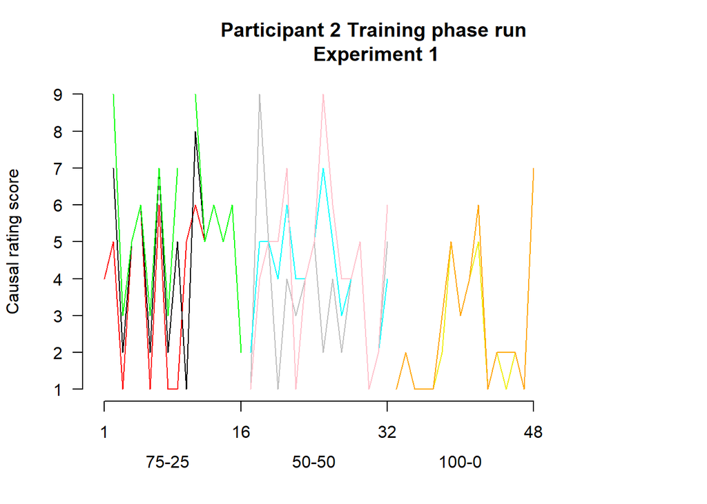

```r
#p2 had Cond 50, 0, 100.
par(mfrow = c(1,1))
par(las = 1)
emptyPlot(c(1,60), c(1,9), xmark = c(1,16,32,48), ymark= c(1,2,3,4,5,6,7,8,9), bty = 'n', main = "Participant 2 Training phase run\n Experiment 1", xlab = "", ylab = "Causal rating score")
points(c(1:16), P2$responseR1[P2$blockNr == "Block1"], type = 'l', col = "red", lty = 1, lwd = 1)
points(c(1:16), P2$responseR2[P2$blockNr == "Block1"], type = 'l', col = "black", lty = 1, lwd = 1)
points(c(1:16), P2$responseR3[P2$blockNr == "Block1"], type = 'l', col = "green", lty = 1, lwd = 1)
points(c(17:32), P2$responseR1[P2$blockNr == "Block2"], type = 'l', col = "grey", lty = 1, lwd = 1)
points(c(17:32), P2$responseR2[P2$blockNr == "Block2"], type = 'l', col = "cyan", lty = 1, lwd = 1)
points(c(17:32), P2$responseR3[P2$blockNr == "Block2"], type = 'l', col = "pink", lty = 1, lwd = 1)
points(c(33:48), P2$responseR1[P2$blockNr == "Block3"], type = 'l', col = "brown", lty = 1, lwd = 1)
points(c(33:48), P2$responseR2[P2$blockNr == "Block3"], type = 'l', col = "yellow2", lty = 1, lwd = 1)
points(c(33:48), P2$responseR3[P2$blockNr == "Block3"], type = 'l', col = "orange", lty = 1, lwd = 1)
mtext("75-25", side = 1, at = 8, line = 2.5)
mtext("50-50", side = 1, at = 24, line = 2.5)
mtext("100-0", side = 1, at = 40, line = 2.5)
```

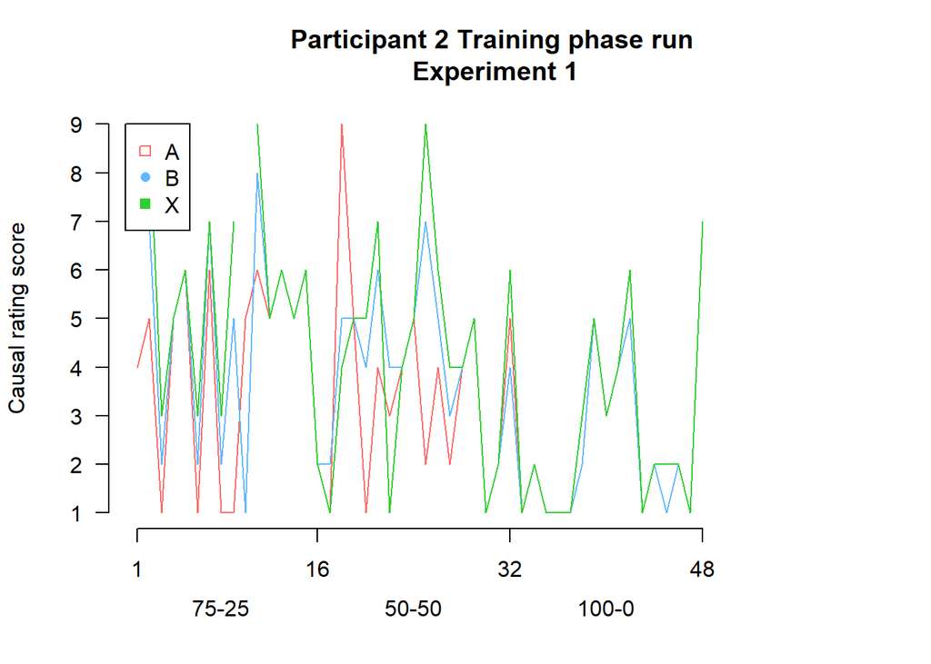

```r
#still P2
par(mfrow = c(1,1))
par(las = 1)
emptyPlot(c(1,60), c(1,9), xmark = c(1,16,32,48), ymark= c(1,2,3,4,5,6,7,8,9), bty = 'n', main = "Participant 2 Training phase run\n Experiment 1", xlab = "", ylab = "Causal rating score")
points(c(1:48), P2$responseR1, type = 'l', col = "indianred1", lty = 1, lwd = 1)
points(c(1:48), P2$responseR2, type = 'l', col = "steelblue1", lty = 1, lwd = 1)
points(c(1:48), P2$responseR3, type = 'l', col = "limegreen", lty = 1, lwd = 1)
mtext("75-25", side = 1, at = 8, line = 2.5)
mtext("50-50", side = 1, at = 24, line = 2.5)
mtext("100-0", side = 1, at = 40, line = 2.5)
legend(0.02,9,legend =c("A", "B", "X"), pch = c(0,16,15), col = c("indianred1", "steelblue1", "limegreen"))
```

Very strange. This participant seems to have big chunks of data missing (e.g look at the A line), however all that data *is* there. There are no NA’s:

```r
P2$responseR1
```

```
##  [1] 4 5 1 5 6 1 6 1 1 5 6 5 6 5 6 2 1 9 5 1 4 3 4 5 2 4 2 4 5 1 2 5 1 2 1 1 1 2
## [39] 5 3 4 5 1 2 2 2 1 7
```

BUT if I plot all of the lines seperately, they are there. This means that the participant scored EXACTLy the same on their X’s and A’s

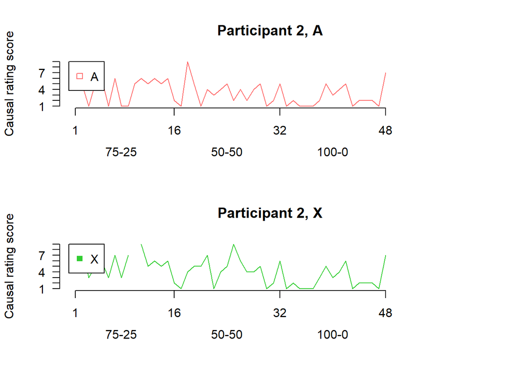

```r
par(mfrow = c(2,1))
par(las = 1)
emptyPlot(c(1,60), c(1,9), xmark = c(1,16,32,48), ymark= c(1,2,3,4,5,6,7,8,9), bty = 'n', main = "Participant 2, A", xlab = "", ylab = "Causal rating score")
points(c(1:48), P2$responseR1, type = 'l', col = "indianred1", lty = 1, lwd = 1)
mtext("75-25", side = 1, at = 8, line = 2.5)
mtext("50-50", side = 1, at = 24, line = 2.5)
mtext("100-0", side = 1, at = 40, line = 2.5)
legend(0.02,9,legend =c("A"), pch = c(0), col = c("indianred1"))

emptyPlot(c(1,60), c(1,9), xmark = c(1,16,32,48), ymark= c(1,2,3,4,5,6,7,8,9), bty = 'n', main = "Participant 2, X", xlab = "", ylab = "Causal rating score")
points(c(1:48), P2$responseR3, type = 'l', col = "limegreen", lty = 1, lwd = 1)
mtext("75-25", side = 1, at = 8, line = 2.5)
mtext("50-50", side = 1, at = 24, line = 2.5)
mtext("100-0", side = 1, at = 40, line = 2.5)
legend(0.02,9,legend =c("X"), pch = c(15), col = c("limegreen"))
```

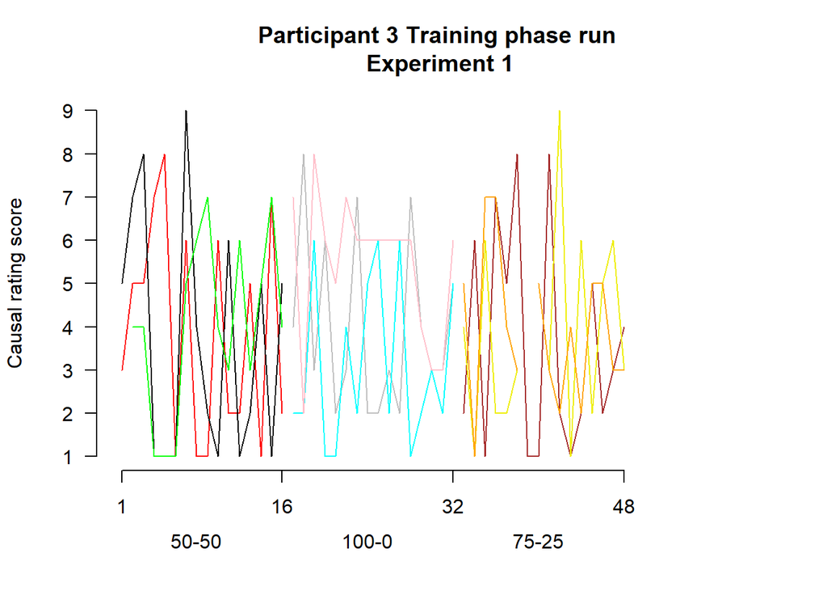

```r
#p3 had Cond 0, 100, 50.
par(mfrow = c(1,1))
par(las = 1)
emptyPlot(c(1,60), c(1,9), xmark = c(1,16,32,48), ymark= c(1,2,3,4,5,6,7,8,9), bty = 'n', main = "Participant 3 Training phase run\n Experiment 1", xlab = "", ylab = "Causal rating score")
points(c(1:16), P3$responseR1[P3$blockNr == "Block1"], type = 'l', col = "red", lty = 1, lwd = 1)
points(c(1:16), P3$responseR2[P3$blockNr == "Block1"], type = 'l', col = "black", lty = 1, lwd = 1)
points(c(1:16), P3$responseR3[P3$blockNr == "Block1"], type = 'l', col = "green", lty = 1, lwd = 1)
points(c(17:32), P3$responseR1[P3$blockNr == "Block2"], type = 'l', col = "grey", lty = 1, lwd = 1)
points(c(17:32), P3$responseR2[P3$blockNr == "Block2"], type = 'l', col = "cyan", lty = 1, lwd = 1)
points(c(17:32), P3$responseR3[P3$blockNr == "Block2"], type = 'l', col = "pink", lty = 1, lwd = 1)
points(c(33:48), P3$responseR1[P3$blockNr == "Block3"], type = 'l', col = "brown", lty = 1, lwd = 1)
points(c(33:48), P3$responseR2[P3$blockNr == "Block3"], type = 'l', col = "yellow2", lty = 1, lwd = 1)
points(c(33:48), P3$responseR3[P3$blockNr == "Block3"], type = 'l', col = "orange", lty = 1, lwd = 1)
mtext("50-50", side = 1, at = 8, line = 2.5)
mtext("100-0", side = 1, at = 24, line = 2.5)
mtext("75-25", side = 1, at = 40, line = 2.5)
```

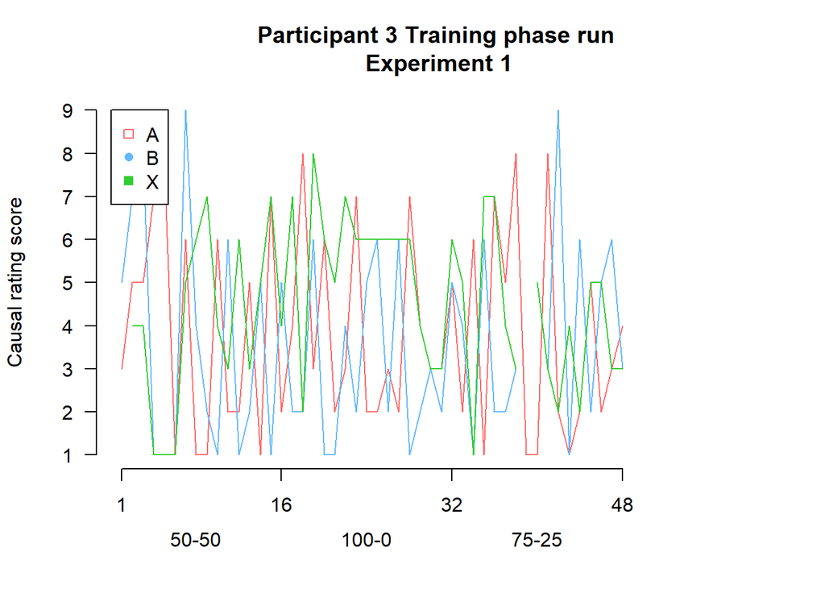

```r
#still P3
par(mfrow = c(1,1))
par(las = 1)
emptyPlot(c(1,60), c(1,9), xmark = c(1,16,32,48), ymark= c(1,2,3,4,5,6,7,8,9), bty = 'n', main = "Participant 3 Training phase run\n Experiment 1", xlab = "", ylab = "Causal rating score")
points(c(1:48), P3$responseR1, type = 'l', col = "indianred1", lty = 1, lwd = 1)
points(c(1:48), P3$responseR2, type = 'l', col = "steelblue1", lty = 1, lwd = 1)
points(c(1:48), P3$responseR3, type = 'l', col = "limegreen", lty = 1, lwd = 1)
mtext("50-50", side = 1, at = 8, line = 2.5)
mtext("100-0", side = 1, at = 24, line = 2.5)
mtext("75-25", side = 1, at = 40, line = 2.5)
legend(0.02,9,legend =c("A", "B", "X"), pch = c(0,16,15), col = c("indianred1", "steelblue1", "limegreen"))
```

## Diamond versus no Diamond trials

```r
#Calculating the average scores on the trials where "Diamond" was the outcome, and on trials where "No Diamond" was the outcome
#We would expect that the scores to the No Diamond would be lower on average
Diamond <- subset(train, train$Outcome == "Diamond.png")
NoDiamond <- subset(train, train$Outcome == "NoDiamond.png")

DiamondAvg <- aggregate(list(Diamond$responseR1, Diamond$responseR2, Diamond$responseR3), list(Diamond$Cond), mean, na.rm = T)
NoDiamondAvg <- aggregate(list(NoDiamond$responseR1, NoDiamond$responseR2, NoDiamond$responseR3), list(NoDiamond$Cond), mean, na.rm = T)
SE <- c(std.error(Diamond$responseR1[Diamond$Cond == "0"]), std.error(NoDiamond$responseR1[NoDiamond$Cond == "0"]), std.error(Diamond$responseR2[Diamond$Cond == "0"]), std.error(NoDiamond$responseR2[NoDiamond$Cond == "0"]), std.error(Diamond$responseR3[Diamond$Cond == "0"]), std.error(NoDiamond$responseR3[NoDiamond$Cond == "0"]),  std.error(Diamond$responseR1[Diamond$Cond == "50"]), std.error(NoDiamond$responseR1[NoDiamond$Cond == "50"]), std.error(Diamond$responseR2[Diamond$Cond == "50"]), std.error(NoDiamond$responseR2[NoDiamond$Cond == "50"]), std.error(Diamond$responseR3[Diamond$Cond == "50"]), std.error(NoDiamond$responseR3[NoDiamond$Cond == "50"]),  std.error(Diamond$responseR1[Diamond$Cond == "100"]), std.error(NoDiamond$responseR1[NoDiamond$Cond == "100"]), std.error(Diamond$responseR2[Diamond$Cond == "100"]), std.error(NoDiamond$responseR2[NoDiamond$Cond == "100"]), std.error(Diamond$responseR3[Diamond$Cond == "100"]), std.error(NoDiamond$responseR3[NoDiamond$Cond == "100"]))
colnames(DiamondAvg) <- c("Cond", "A", "B", "X")
colnames(NoDiamondAvg) <- c("Cond", "A", "B", "X")

DiamondAvg
```

```
##   Cond        A        B        X
## 1    0 4.514706 3.906183 5.186551
## 2   50 4.941423 3.694444 5.410753
## 3  100 5.440252 3.447983 5.221277
```

```r
NoDiamondAvg
```

```
##   Cond        A        B        X
## 1    0 4.008386 3.523305 4.576923
## 2   50 3.884696 3.459746 4.339744
## 3  100 4.010438 3.390397 4.362288
```

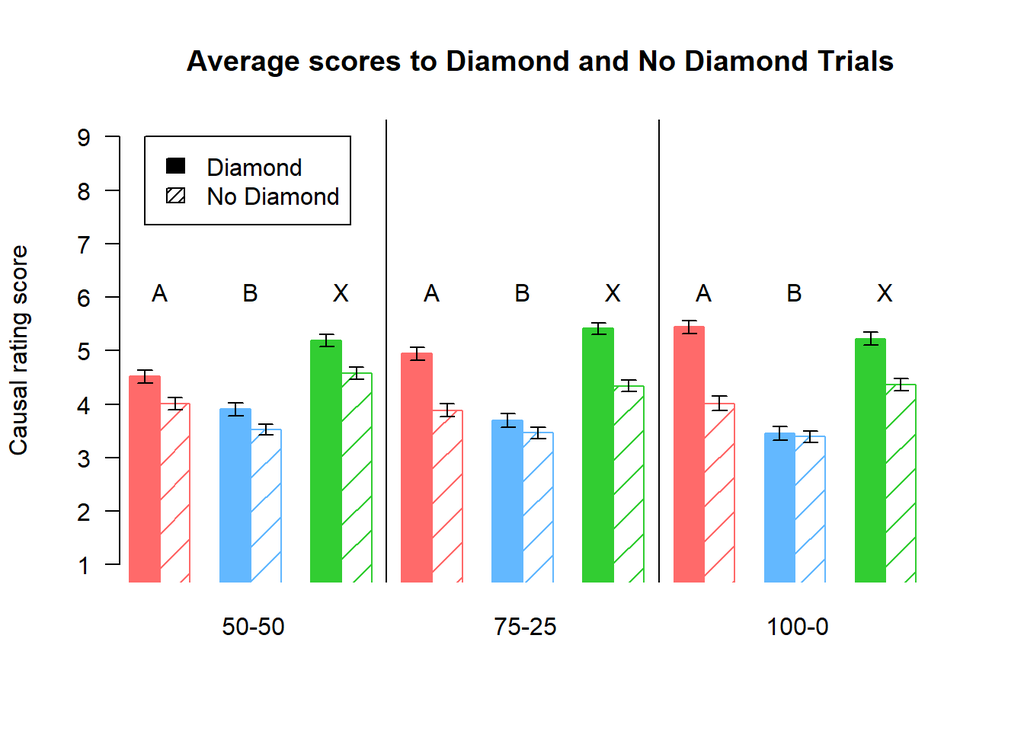

```r
par(mfrow = c(1,1))
par(las = 1)
emptyPlot(c(1,130), c(1,9), xaxt = "none", ymark= c(1,2,3,4,5,6, 7, 8,9), bty = 'n', main = "Average scores to Diamond and No Diamond Trials", xlab = "", ylab = "Causal rating score")
add_bars(x=c(0,5,15,20,30,35, 45,50,60,65,75,80, 90,95,105,110,120,125), y=c(DiamondAvg$A[DiamondAvg$Cond == "0"], NoDiamondAvg$A[NoDiamondAvg$Cond == "0"], DiamondAvg$B[DiamondAvg$Cond == "0"], NoDiamondAvg$B[NoDiamondAvg$Cond == "0"],DiamondAvg$X[DiamondAvg$Cond == "0"], NoDiamondAvg$X[NoDiamondAvg$Cond == "0"], DiamondAvg$A[DiamondAvg$Cond == "50"], NoDiamondAvg$A[NoDiamondAvg$Cond == "50"], DiamondAvg$B[DiamondAvg$Cond == "50"], NoDiamondAvg$B[NoDiamondAvg$Cond == "50"],DiamondAvg$X[DiamondAvg$Cond == "50"], NoDiamondAvg$X[NoDiamondAvg$Cond == "50"], DiamondAvg$A[DiamondAvg$Cond == "100"], NoDiamondAvg$A[NoDiamondAvg$Cond == "100"], DiamondAvg$B[DiamondAvg$Cond == "100"], NoDiamondAvg$B[NoDiamondAvg$Cond == "100"],DiamondAvg$X[DiamondAvg$Cond == "100"], NoDiamondAvg$X[NoDiamondAvg$Cond == "100"]), width = 5, col = c("indianred1", "indianred1", "steelblue1", "steelblue1", "limegreen", "limegreen"), density = c(200,6))

errorbars(x=c(0,5,15,20,30,35, 45,50,60,65,75,80, 90,95,105,110,120,125), y=c(DiamondAvg$A[DiamondAvg$Cond == "0"], NoDiamondAvg$A[NoDiamondAvg$Cond == "0"], DiamondAvg$B[DiamondAvg$Cond == "0"], NoDiamondAvg$B[NoDiamondAvg$Cond == "0"],DiamondAvg$X[DiamondAvg$Cond == "0"], NoDiamondAvg$X[NoDiamondAvg$Cond == "0"], DiamondAvg$A[DiamondAvg$Cond == "50"], NoDiamondAvg$A[NoDiamondAvg$Cond == "50"], DiamondAvg$B[DiamondAvg$Cond == "50"], NoDiamondAvg$B[NoDiamondAvg$Cond == "50"],DiamondAvg$X[DiamondAvg$Cond == "50"], NoDiamondAvg$X[NoDiamondAvg$Cond == "50"], DiamondAvg$A[DiamondAvg$Cond == "100"], NoDiamondAvg$A[NoDiamondAvg$Cond == "100"], DiamondAvg$B[DiamondAvg$Cond == "100"], NoDiamondAvg$B[NoDiamondAvg$Cond == "100"],DiamondAvg$X[DiamondAvg$Cond == "100"], NoDiamondAvg$X[NoDiamondAvg$Cond == "100"]) , top = SE , bottom = SE, add = TRUE, length = .05)

abline(v=40, col="grey2", lty = 1)
abline(v=85, col="grey2", lty = 1)
#condition text
mtext("50-50", side = 1, at = 18, line = 1)
mtext("75-25", side = 1, at = 63, line = 1)
mtext("100-0", side = 1, at = 108, line = 1)
#letters
text(x=2.5, y = 6.1, labels = "A")
text(x=47.5, y = 6.1, labels = "A")
text(x=92.5, y = 6.1, labels = "A")
text(x=17.5, y = 6.1, labels = "B")
text(x=62.5, y = 6.1, labels = "B")
text(x=107.5, y = 6.1, labels = "B")
text(x=32.5, y = 6.1, labels = "X")
text(x=77.5, y = 6.1, labels = "X")
text(x=122.5, y = 6.1, labels = "X")
legend(x=0, y = 9, legend =c("Diamond", "No Diamond"), density = c(200,20), col= c("indianred1"))
```

```r
#c("indianred1", "indianred3", "steelblue1", "steelblue3", "limegreen", "palegreen4"))

SE
```

```
##  [1] 0.1229682 0.1152526 0.1196804 0.1013987 0.1130868 0.1081903 0.1215447
##  [8] 0.1184691 0.1217807 0.1076702 0.1086401 0.1090906 0.1237582 0.1323224
## [15] 0.1258207 0.1072163 0.1185317 0.1156042
```

```r
range(SE)
```

```
## [1] 0.1013987 0.1323224
```

# Test phase

I just plot the cues over condition

```
##    Cue Cond  Diamond   Fossil
## 1   A1    0 4.523810 3.500000
## 2   A1   50 4.138889 4.472222
## 3   A1  100 4.487805 3.951220
## 4   B1    0 4.857143 3.500000
## 5   B1   50 4.444444 4.861111
## 6   B1  100 4.975610 3.121951
## 7   X1    0 5.611111 4.269841
## 8   X1   50 5.101852 4.925234
## 9   X1  100 5.260163 4.612903
## 10   C   NA 3.588235 3.883333
## 11  A3    0 6.700000 3.300000
## 12  A3   50 6.142857 3.857143
## 13  A3  100 5.833333 3.895833
## 14  B3    0 2.500000 5.300000
## 15  B3   50 3.428571 3.880952
## 16  B3  100 3.187500 3.729167
## 17  X3    0 4.516667 4.933333
## 18  X3   50 5.321429 4.535714
## 19  X3  100 5.062500 4.260417
```

```r
#and now to add on to that, the original ones

#now that we know what was asked when in the training phase
#we only take the last response just as before
ABl1000 <- mean(train$responseR1[train$blockNr == "Block1" & train$Cond == "0" & train$Trial == 15], na.rm = T)
ABl1050 <- mean(train$responseR1[train$blockNr == "Block1" & train$Cond == "50" & train$Trial == 15], na.rm = T)
ABl1100 <- mean(train$responseR1[train$blockNr == "Block1" & train$Cond == "100" & train$Trial == 15], na.rm = T)

BBl1000 <- mean(train$responseR2[train$blockNr == "Block1" & train$Cond == "0" & train$Trial == 16], na.rm = T)
BBl1050 <- mean(train$responseR2[train$blockNr == "Block1" & train$Cond == "50" & train$Trial == 16], na.rm = T)
BBl1100 <- mean(train$responseR2[train$blockNr == "Block1" & train$Cond == "100" & train$Trial == 16], na.rm = T)

XBl1000 <- mean(train$responseR3[train$blockNr == "Block1" & train$Cond == "0" & train$Trial == 16], na.rm = T)
XBl1050 <- mean(train$responseR3[train$blockNr == "Block1" & train$Cond == "50" & train$Trial == 16], na.rm = T)
XBl1100 <- mean(train$responseR3[train$blockNr == "Block1" & train$Cond == "100" & train$Trial == 16], na.rm = T)

ABl3000 <- mean(train$responseR1[train$blockNr == "Block3" & train$Cond == "0" & train$Trial == 15], na.rm = T)
ABl3050 <- mean(train$responseR1[train$blockNr == "Block3" & train$Cond == "50" & train$Trial == 15], na.rm = T)
ABl3100 <- mean(train$responseR1[train$blockNr == "Block3" & train$Cond == "100" & train$Trial == 15], na.rm = T)

BBl3000 <- mean(train$responseR2[train$blockNr == "Block3" & train$Cond == "0" & train$Trial == 16], na.rm = T)
BBl3050 <- mean(train$responseR2[train$blockNr == "Block3" & train$Cond == "50" & train$Trial == 16], na.rm = T)
BBl3100 <- mean(train$responseR2[train$blockNr == "Block3" & train$Cond == "100" & train$Trial == 16], na.rm = T)

XBl3000 <- mean(train$responseR3[train$blockNr == "Block3" & train$Cond == "0"& train$Trial == 16], na.rm = T)
XBl3050 <- mean(train$responseR3[train$blockNr == "Block3" & train$Cond == "50"& train$Trial == 16], na.rm = T)
XBl3100 <- mean(train$responseR3[train$blockNr == "Block3" & train$Cond == "100"& train$Trial == 16], na.rm = T)

Original <- c(ABl1000, ABl1050, ABl1100, BBl1000, BBl1050, BBl1100, XBl1000, XBl1050, XBl1100, "NA", ABl3000, ABl3050, ABl3100, BBl3000, BBl3050, BBl3100, XBl3000, XBl3050, XBl3100)
Phase1Split$Original <- as.numeric(Original)
Phase1Split
```

```
##    Cue Cond  Diamond   Fossil Original
## 1   A1    0 4.523810 3.500000 5.142857
## 2   A1   50 4.138889 4.472222 6.222222
## 3   A1  100 4.487805 3.951220 6.380952
## 4   B1    0 4.857143 3.500000 4.428571
## 5   B1   50 4.444444 4.861111 3.833333
## 6   B1  100 4.975610 3.121951 2.950000
## 7   X1    0 5.611111 4.269841 4.952381
## 8   X1   50 5.101852 4.925234 4.277778
## 9   X1  100 5.260163 4.612903 4.315789
## 10   C   NA 3.588235 3.883333       NA
## 11  A3    0 6.700000 3.300000 4.466667
## 12  A3   50 6.142857 3.857143 5.095238
## 13  A3  100 5.833333 3.895833 6.583333
## 14  B3    0 2.500000 5.300000 3.733333
## 15  B3   50 3.428571 3.880952 3.800000
## 16  B3  100 3.187500 3.729167 2.666667
## 17  X3    0 4.516667 4.933333 4.866667
## 18  X3   50 5.321429 4.535714 5.100000
## 19  X3  100 5.062500 4.260417 3.291667
```

```r
A1D12000 <- aggregate(list(A1D12000$responseR1), by = list(A1D12000$prolific_id), mean, na.rm = T)
names(A1D12000) <- c("Participant", "responseR1")
A1D12050 <- aggregate(list(A1D12050$responseR1), by = list(A1D12050$prolific_id), mean, na.rm = T)
names(A1D12050) <- c("Participant", "responseR1")
A1D12100 <- aggregate(list(A1D12100$responseR1), by = list(A1D12100$prolific_id), mean, na.rm = T)
names(A1D12100) <- c("Participant", "responseR1")

B1D12000 <- aggregate(list(B1D12000$responseR1), by = list(B1D12000$prolific_id), mean, na.rm = T)
names(B1D12000) <- c("Participant", "responseR1")
B1D12050 <- aggregate(list(B1D12050$responseR1), by = list(B1D12050$prolific_id), mean, na.rm = T)
names(B1D12050) <- c("Participant", "responseR1")
B1D12100 <- aggregate(list(B1D12100$responseR1), by = list(B1D12100$prolific_id), mean, na.rm = T)
names(B1D12100) <- c("Participant", "responseR1")

X1D12000 <- aggregate(list(X1D12000$responseR2), by = list(X1D12000$prolific_id), mean, na.rm = T)
names(X1D12000) <- c("Participant", "responseR2")
X1D12050 <- aggregate(list(X1D12050$responseR2), by = list(X1D12050$prolific_id), mean, na.rm = T)
names(X1D12050) <- c("Participant", "responseR2")
X1D12100 <- aggregate(list(X1D12100$responseR2), by = list(X1D12100$prolific_id), mean, na.rm = T)
names(X1D12100) <- c("Participant", "responseR2")

A3D12000 <- aggregate(list(A3D12000$responseR1), by = list(A3D12000$prolific_id), mean, na.rm = T)
names(A3D12000) <- c("Participant", "responseR1")
A3D12050 <- aggregate(list(A3D12050$responseR1), by = list(A3D12050$prolific_id), mean, na.rm = T)
names(A3D12050) <- c("Participant", "responseR1")
A3D12100 <- aggregate(list(A3D12100$responseR1), by = list(A3D12100$prolific_id), mean, na.rm = T)
names(A3D12100) <- c("Participant", "responseR1")

B3D12000 <- aggregate(list(B3D12000$responseR1), by = list(B3D12000$prolific_id), mean, na.rm = T)
names(B3D12000) <- c("Participant", "responseR1")
B3D12050 <- aggregate(list(B3D12050$responseR1), by = list(B3D12050$prolific_id), mean, na.rm = T)
names(B3D12050) <- c("Participant", "responseR1")
B3D12100 <- aggregate(list(B3D12100$responseR1), by = list(B3D12100$prolific_id), mean, na.rm = T)
names(B3D12100) <- c("Participant", "responseR1")


X3D12000 <- aggregate(list(X3D12000$responseR2), by = list(X3D12000$prolific_id), mean, na.rm = T)
names(X3D12000) <- c("Participant", "responseR2")
X3D12050 <- aggregate(list(X3D12050$responseR2), by = list(X3D12050$prolific_id), mean, na.rm = T)
names(X3D12050) <- c("Participant", "responseR2")
X3D12100 <- aggregate(list(X3D12100$responseR2), by = list(X3D12100$prolific_id), mean, na.rm = T)
names(X3D12100) <- c("Participant", "responseR2")


A1F12000 <- aggregate(list(A1F12000$responseR1), by = list(A1F12000$prolific_id), mean, na.rm = T)
names(A1F12000) <- c("Participant", "responseR1")
A1F12050 <- aggregate(list(A1F12050$responseR1), by = list(A1F12050$prolific_id), mean, na.rm = T)
names(A1F12050) <- c("Participant", "responseR1")
A1F12100 <- aggregate(list(A1F12100$responseR1), by = list(A1F12100$prolific_id), mean, na.rm = T)
names(A1F12100) <- c("Participant", "responseR1")

B1F12000 <- aggregate(list(B1F12000$responseR1), by = list(B1F12000$prolific_id), mean, na.rm = T)
names(B1F12000) <- c("Participant", "responseR1")
B1F12050 <- aggregate(list(B1F12050$responseR1), by = list(B1F12050$prolific_id), mean, na.rm = T)
names(B1F12050) <- c("Participant", "responseR1")
B1F12100 <- aggregate(list(B1F12100$responseR1), by = list(B1F12100$prolific_id), mean, na.rm = T)
names(B1F12100) <- c("Participant", "responseR1")

X1F12000 <- aggregate(list(X1F12000$responseR2), by = list(X1F12000$prolific_id), mean, na.rm = T)
names(X1F12000) <- c("Participant", "responseR2")
X1F12050 <- aggregate(list(X1F12050$responseR2), by = list(X1F12050$prolific_id), mean, na.rm = T)
names(X1F12050) <- c("Participant", "responseR2")
X1F12100 <- aggregate(list(X1F12100$responseR2), by = list(X1F12100$prolific_id), mean, na.rm = T)
names(X1F12100) <- c("Participant", "responseR2")

A3F12000 <- aggregate(list(A3F12000$responseR1), by = list(A3F12000$prolific_id), mean, na.rm = T)
names(A3F12000) <- c("Participant", "responseR1")
A3F12050 <- aggregate(list(A3F12050$responseR1), by = list(A3F12050$prolific_id), mean, na.rm = T)
names(A3F12050) <- c("Participant", "responseR1")
A3F12100 <- aggregate(list(A3F12100$responseR1), by = list(A3F12100$prolific_id), mean, na.rm = T)
names(A3F12100) <- c("Participant", "responseR1")

B3F12000 <- aggregate(list(B3F12000$responseR1), by = list(B3F12000$prolific_id), mean, na.rm = T)
names(B3F12000) <- c("Participant", "responseR1")
B3F12050 <- aggregate(list(B3F12050$responseR1), by = list(B3F12050$prolific_id), mean, na.rm = T)
names(B3F12050) <- c("Participant", "responseR1")
B3F12100 <- aggregate(list(B3F12100$responseR1), by = list(B3F12100$prolific_id), mean, na.rm = T)
names(B3F12100) <- c("Participant", "responseR1")


X3F12000 <- aggregate(list(X3F12000$responseR2), by = list(X3F12000$prolific_id), mean, na.rm = T)
names(X3F12000) <- c("Participant", "responseR2")
X3F12050 <- aggregate(list(X3F12050$responseR2), by = list(X3F12050$prolific_id), mean, na.rm = T)
names(X3F12050) <- c("Participant", "responseR2")
X3F12100 <- aggregate(list(X3F12100$responseR2), by = list(X3F12100$prolific_id), mean, na.rm = T)
names(X3F12100) <- c("Participant", "responseR2")
```

## Test vs train

### Block 1

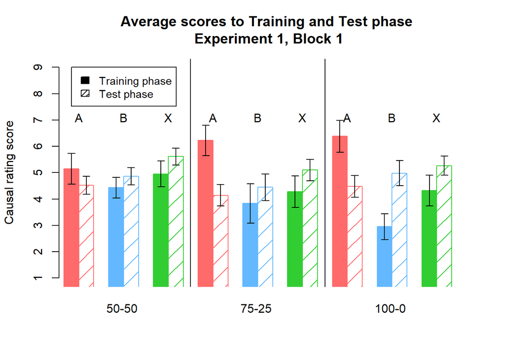

```r
#andersom!!

SE_Bl1 <- c(std.error(train$responseR1[train$blockNr == "Block1" & train$Cond == "0" & train$Trial == 15]),
            std.error(A1D12000$responseR1),
            std.error(train$responseR2[train$blockNr == "Block1" & train$Cond == "0" & train$Trial == 16]),
            std.error(B1D12000$responseR1),
            std.error(train$responseR3[train$blockNr == "Block1" & train$Cond == "0" & train$Trial == 16]),
            std.error(X1D12000$responseR2),
            std.error(train$responseR1[train$blockNr == "Block1" & train$Cond == "50" & train$Trial == 15]),
            std.error(A1D12050$responseR1),
            std.error(train$responseR2[train$blockNr == "Block1" & train$Cond == "50" & train$Trial == 16]),
            std.error(B1D12050$responseR1),
            std.error(train$responseR3[train$blockNr == "Block1" & train$Cond == "50" & train$Trial == 16]),
            std.error(X1D12050$responseR2),
            std.error(train$responseR1[train$blockNr == "Block1" & train$Cond == "100" & train$Trial == 15]),
            std.error(A1D12100$responseR1),
            std.error(train$responseR2[train$blockNr == "Block1" & train$Cond == "100" & train$Trial == 16]),
            std.error(B1D12100$responseR1),
            std.error(train$responseR3[train$blockNr == "Block1" & train$Cond == "100" & train$Trial == 16]),
            std.error(X1D12100$responseR2))
par(mfrow = c(1,1))
par(las = 0)
emptyPlot(c(1,130), c(1,9), xaxt = "none", ymark= c(1,2,3,4,5,6,7,8,9), bty = 'n', main = "Average scores to Training and Test phase\n Experiment 1, Block 1", xlab = "", ylab = "Causal rating score")
add_bars(x=c(0,5, 15,20 ,30,35, 45,50, 60,65, 75,80, 90,95, 105,110, 120,125), y= c(ABl1000, mean(A1D12000$responseR1, na.rm = T), BBl1000, mean(B1D12000$responseR1, na.rm = T), XBl1000, mean(X1D12000$responseR2, na.rm = T),  ABl1050, mean(A1D12050$responseR1, na.rm = T), BBl1050, mean(B1D12050$responseR1, na.rm = T), XBl1050, mean(X1D12050$responseR2, na.rm = T),  ABl1100, mean(A1D12100$responseR1, na.rm = T), BBl1100, mean(B1D12100$responseR1, na.rm = T), XBl1100, mean(X1D12100$responseR2, na.rm = T)), width = 5, col = c("indianred1", "indianred1", "steelblue1", "steelblue1", "limegreen", "limegreen"), density = c(200,6))
errorbars(x=c(0,5, 15,20 ,30,35, 45,50, 60,65, 75,80, 90,95, 105,110, 120,125), c(ABl1000, mean(A1D12000$responseR1, na.rm = T), BBl1000, mean(B1D12000$responseR1, na.rm = T), XBl1000, mean(X1D12000$responseR2, na.rm = T),  ABl1050, mean(A1D12050$responseR1, na.rm = T), BBl1050, mean(B1D12050$responseR1, na.rm = T), XBl1050, mean(X1D12050$responseR2, na.rm = T),  ABl1100, mean(A1D12100$responseR1, na.rm = T), BBl1100, mean(B1D12100$responseR1, na.rm = T), XBl1100, mean(X1D12100$responseR2, na.rm = T)) , top = SE_Bl1 , bottom = SE_Bl1, add = TRUE, length = .05)
abline(v=40, col="grey2", lty = 1)
abline(v=85, col="grey2", lty = 1)
#condition text
mtext("50-50", side = 1, at = 17, line = 1)
mtext("75-25", side = 1, at = 62, line = 1)
mtext("100-0", side = 1, at = 107, line = 1)
#letters
text(x=2.5, y = 7.1, labels = "A")
text(x=17.5, y = 7.1, labels = "B")
text(x=32.5, y = 7.1, labels = "X")
text(x=47.5, y = 7.1, labels = "A")
text(x=62.5, y = 7.1, labels = "B")
text(x=77.5, y = 7.1, labels = "X")
text(x=92.5, y = 7.1, labels = "A")
text(x=107.5, y = 7.1, labels = "B")
text(x=122.5, y = 7.1, labels = "X")
legend(x=0, y = 9, legend = c("Training phase", "Test phase"), density = c(200,20),cex = 0.9)
```

### Block 3

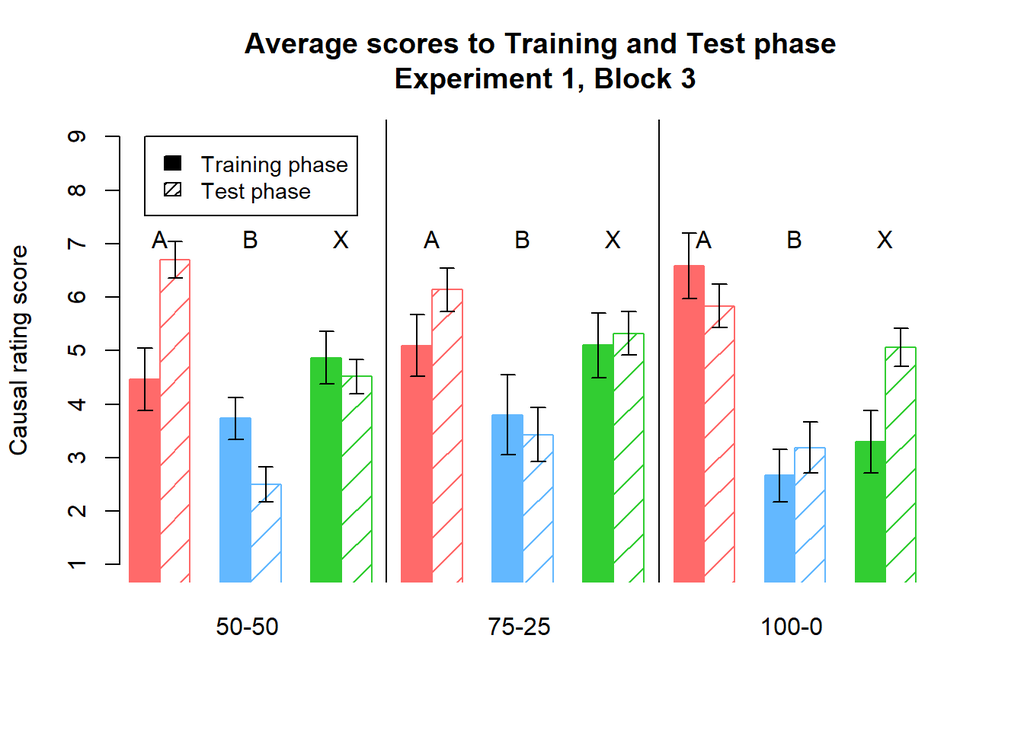

```r
SE_Bl3 <- c(std.error(train$responseR1[train$blockNr == "Block3" & train$Cond == "0" & train$Trial == 15]),
            std.error(A3D12000$responseR1),
            std.error(train$responseR2[train$blockNr == "Block3" & train$Cond == "0" & train$Trial == 16]),
            std.error(B3D12000$responseR1),
            std.error(train$responseR3[train$blockNr == "Block3" & train$Cond == "0" & train$Trial == 16]),
            std.error(X3D12000$responseR2),
            std.error(train$responseR1[train$blockNr == "Block3" & train$Cond == "50" & train$Trial == 15]),
            std.error(A3D12050$responseR1),
            std.error(train$responseR2[train$blockNr == "Block3" & train$Cond == "50" & train$Trial == 16]),
            std.error(B3D12050$responseR1),
            std.error(train$responseR3[train$blockNr == "Block3" & train$Cond == "50" & train$Trial == 16]),
            std.error(X3D12050$responseR2),
            std.error(train$responseR1[train$blockNr == "Block3" & train$Cond == "100" & train$Trial == 15]),
            std.error(A3D12100$responseR1),
            std.error(train$responseR2[train$blockNr == "Block3" & train$Cond == "100" & train$Trial == 16]),
            std.error(B3D12100$responseR1),
            std.error(train$responseR3[train$blockNr == "Block3" & train$Cond == "100" & train$Trial == 16]),
            std.error(X3D12100$responseR2))

par(mfrow = c(1,1))
par(las = 0)
emptyPlot(c(1,130), c(1,9), xaxt = "none", ymark= c(1,2,3,4,5,6,7,8,9), bty = 'n', main = "Average scores to Training and Test phase\n Experiment 1, Block 3", xlab = "", ylab = "Causal rating score")
add_bars(x=c(0,5, 15,20 ,30,35, 45,50, 60,65, 75,80, 90,95, 105,110, 120,125), y= c(ABl3000, mean(A3D12000$responseR1, na.rm = T), BBl3000, mean(B3D12000$responseR1, na.rm = T), XBl3000, mean(X3D12000$responseR2, na.rm = T),  ABl3050, mean(A3D12050$responseR1, na.rm = T), BBl3050, mean(B3D12050$responseR1, na.rm = T), XBl3050, mean(X3D12050$responseR2, na.rm = T),  ABl3100, mean(A3D12100$responseR1, na.rm = T), BBl3100, mean(B3D12100$responseR1, na.rm = T), XBl3100, mean(X3D12100$responseR2, na.rm = T)), width = 5, col = c("indianred1", "indianred1", "steelblue1", "steelblue1", "limegreen", "limegreen"), density = c(200,6))
errorbars(x=c(0,5, 15,20 ,30,35, 45,50, 60,65, 75,80, 90,95, 105,110, 120,125), c(ABl3000, mean(A3D12000$responseR1, na.rm = T), BBl3000, mean(B3D12000$responseR1, na.rm = T), XBl3000, mean(X3D12000$responseR2, na.rm = T),  ABl3050, mean(A3D12050$responseR1, na.rm = T), BBl3050, mean(B3D12050$responseR1, na.rm = T), XBl3050, mean(X3D12050$responseR2, na.rm = T),  ABl3100, mean(A3D12100$responseR1, na.rm = T), BBl3100, mean(B3D12100$responseR1, na.rm = T), XBl3100, mean(X3D12100$responseR2, na.rm = T)) , top = SE_Bl1 , bottom = SE_Bl1, add = TRUE, length = .05)
abline(v=40, col="grey2", lty = 1)
abline(v=85, col="grey2", lty = 1)
#condition text
mtext("50-50", side = 1, at = 17, line = 1)
mtext("75-25", side = 1, at = 62, line = 1)
mtext("100-0", side = 1, at = 107, line = 1)
#letters
text(x=2.5, y = 7.1, labels = "A")
text(x=17.5, y = 7.1, labels = "B")
text(x=32.5, y = 7.1, labels = "X")
text(x=47.5, y = 7.1, labels = "A")
text(x=62.5, y = 7.1, labels = "B")
text(x=77.5, y = 7.1, labels = "X")
text(x=92.5, y = 7.1, labels = "A")
text(x=107.5, y = 7.1, labels = "B")
text(x=122.5, y = 7.1, labels = "X")
legend(x=0, y = 9, legend = c("Training phase", "Test phase"), density = c(200,20),cex = 0.9)
```

## Cues vs C

### Block 1

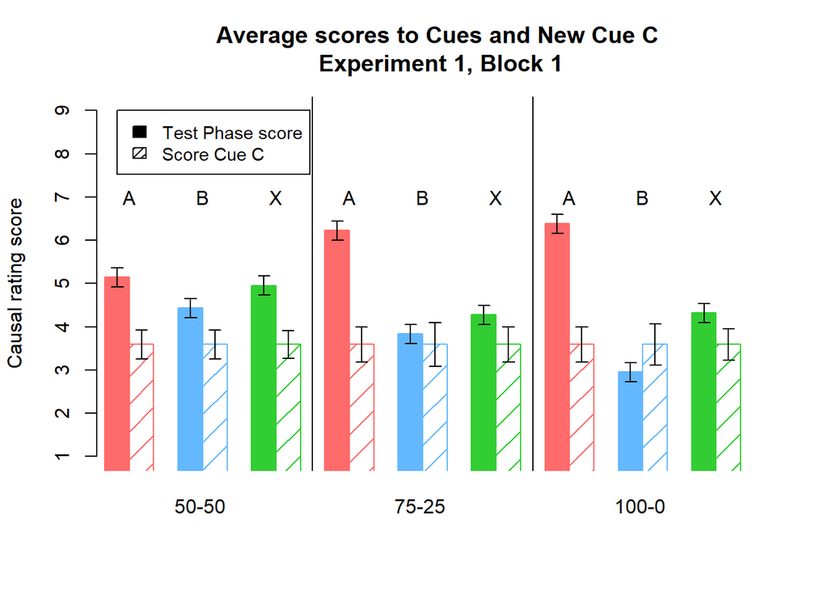

```r
SE_CBl1 <- c(std.error(CD12$responseR1),
             std.error(A1D12000$responseR1),
             std.error(CD12$responseR1),
             std.error(B1D12000$responseR1),
             std.error(CD12$responseR1),
             std.error(X1D12000$responseR2),
             std.error(CD12$responseR1),
             std.error(A1D12050$responseR1),
             std.error(CD12$responseR1),
             std.error(B1D12050$responseR1),
             std.error(CD12$responseR1),
             std.error(X1D12050$responseR2),
             std.error(CD12$responseR1),
             std.error(A1D12100$responseR1),
             std.error(CD12$responseR1),
             std.error(B1D12100$responseR1),
             std.error(CD12$responseR1),
             std.error(X1D12100$responseR2))

#CD12 <- testD12[which(testD12$Trial == 5),]
#avgCD12 <- mean(CD12$responseR1, na.rm = T)

par(mfrow = c(1,1))
par(las = 0)
emptyPlot(c(1,130), c(1,9), xaxt = "none", ymark= c(1,2,3,4,5,6,7,8,9), bty = 'n', main = "Average scores to Cues and New Cue C\n Experiment 1, Block 1", xlab = "", ylab = "Causal rating score")
add_bars(x=c(0,5, 15,20 ,30,35, 45,50, 60,65, 75,80, 90,95, 105,110, 120,125), y= c(ABl1000, mean(CD12$responseR1, na.rm = T), BBl1000, mean(CD12$responseR1, na.rm = T), XBl1000, mean(CD12$responseR1, na.rm = T),  ABl1050, mean(CD12$responseR1, na.rm = T), BBl1050, mean(CD12$responseR1, na.rm = T), XBl1050, mean(CD12$responseR1, na.rm = T),  ABl1100, mean(CD12$responseR1, na.rm = T), BBl1100, mean(CD12$responseR1, na.rm = T), XBl1100, mean(CD12$responseR1, na.rm = T)), width = 5, col = c("indianred1", "indianred1", "steelblue1", "steelblue1", "limegreen", "limegreen"), density = c(200,6))
errorbars(x=c(0,5, 15,20 ,30,35, 45,50, 60,65, 75,80, 90,95, 105,110, 120,125), c(ABl1000, mean(CD12$responseR1, na.rm = T), BBl1000, mean(CD12$responseR1, na.rm = T), XBl1000, mean(CD12$responseR1, na.rm = T),  ABl1050, mean(CD12$responseR1, na.rm = T), BBl1050, mean(CD12$responseR1, na.rm = T), XBl1050, mean(CD12$responseR1, na.rm = T),  ABl1100, mean(CD12$responseR1, na.rm = T), BBl1100, mean(CD12$responseR1, na.rm = T), XBl1100, mean(CD12$responseR1, na.rm = T)) , top = SE_CBl1 , bottom = SE_CBl1, add = TRUE, length = .05)
abline(v=40, col="grey2", lty = 1)
abline(v=85, col="grey2", lty = 1)
#condition text
mtext("50-50", side = 1, at = 17, line = 1)
mtext("75-25", side = 1, at = 62, line = 1)
mtext("100-0", side = 1, at = 107, line = 1)
#letters
text(x=2.5, y = 7.0, labels = "A")
text(x=17.5, y = 7.0, labels = "B")
text(x=32.5, y = 7.0, labels = "X")
text(x=47.5, y = 7.0, labels = "A")
text(x=62.5, y = 7.0, labels = "B")
text(x=77.5, y = 7.0, labels = "X")
text(x=92.5, y = 7.0, labels = "A")
text(x=107.5, y = 7.0, labels = "B")
text(x=122.5, y = 7.0, labels = "X")
legend(x=0, y = 9, legend = c("Test Phase score", "Score Cue C"), density = c(200,20),cex = 0.9)
```

### Block 3

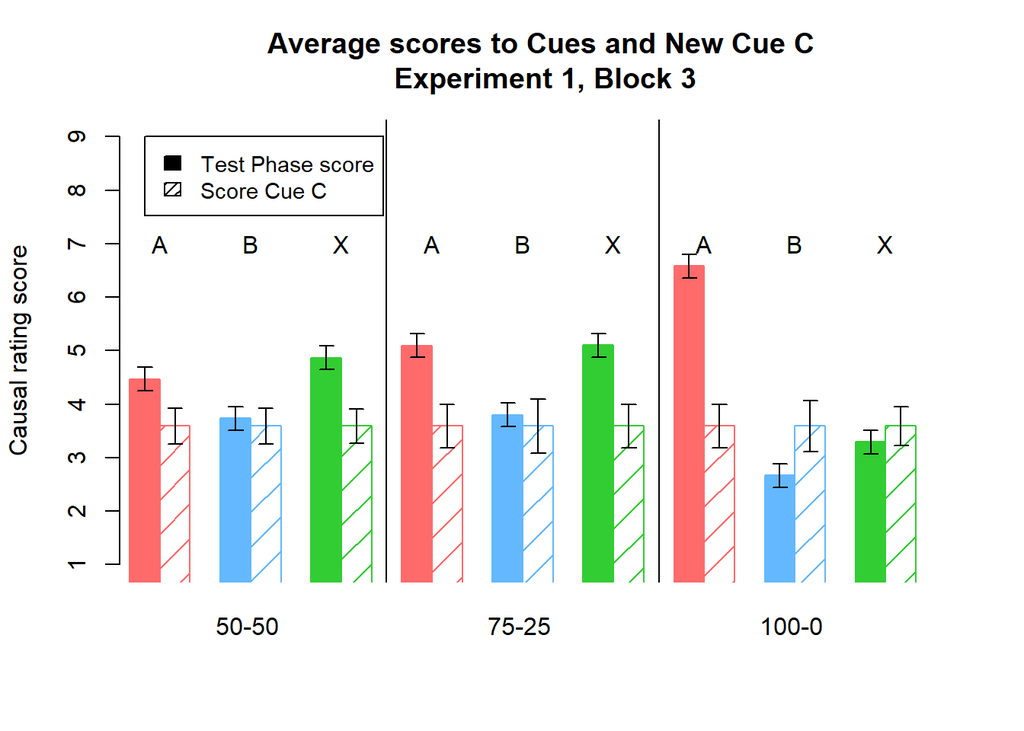

```r
SE_CBl3 <- c(std.error(CD12$responseR1),
             std.error(A3D12000$responseR1),
             std.error(CD12$responseR1),
             std.error(B3D12000$responseR1),
             std.error(CD12$responseR1),
             std.error(X3D12000$responseR2),
             std.error(CD12$responseR1),
             std.error(A3D12050$responseR1),
             std.error(CD12$responseR1),
             std.error(B3D12050$responseR1),
             std.error(CD12$responseR1),
             std.error(X3D12050$responseR2),
             std.error(CD12$responseR1),
             std.error(A3D12100$responseR1),
             std.error(CD12$responseR1),
             std.error(B3D12100$responseR1),
             std.error(CD12$responseR1),
             std.error(X3D12100$responseR2))

#CD12 <- testD12[which(testD12$Trial == 5),]
#avgCD12 <- mean(CD12$responseR1, na.rm = T)

par(mfrow = c(1,1))
par(las = 0)
emptyPlot(c(1,130), c(1,9), xaxt = "none", ymark= c(1,2,3,4,5,6,7,8,9), bty = 'n', main = "Average scores to Cues and New Cue C\n Experiment 1, Block 3", xlab = "", ylab = "Causal rating score")
add_bars(x=c(0,5, 15,20 ,30,35, 45,50, 60,65, 75,80, 90,95, 105,110, 120,125), y= c(ABl3000, mean(CD12$responseR1, na.rm = T), BBl3000, mean(CD12$responseR1, na.rm = T), XBl3000, mean(CD12$responseR1, na.rm = T),  ABl3050, mean(CD12$responseR1, na.rm = T), BBl3050, mean(CD12$responseR1, na.rm = T), XBl3050, mean(CD12$responseR1, na.rm = T),  ABl3100, mean(CD12$responseR1, na.rm = T), BBl3100, mean(CD12$responseR1, na.rm = T), XBl3100, mean(CD12$responseR1, na.rm = T)), width = 5, col = c("indianred1", "indianred1", "steelblue1", "steelblue1", "limegreen", "limegreen"), density = c(200,6))
errorbars(x=c(0,5, 15,20 ,30,35, 45,50, 60,65, 75,80, 90,95, 105,110, 120,125), c(ABl3000, mean(CD12$responseR1, na.rm = T), BBl3000, mean(CD12$responseR1, na.rm = T), XBl3000, mean(CD12$responseR1, na.rm = T),  ABl3050, mean(CD12$responseR1, na.rm = T), BBl3050, mean(CD12$responseR1, na.rm = T), XBl3050, mean(CD12$responseR1, na.rm = T),  ABl3100, mean(CD12$responseR1, na.rm = T), BBl3100, mean(CD12$responseR1, na.rm = T), XBl3100, mean(CD12$responseR1, na.rm = T)) , top = SE_CBl1 , bottom = SE_CBl1, add = TRUE, length = .05)
abline(v=40, col="grey2", lty = 1)
abline(v=85, col="grey2", lty = 1)
#condition text
mtext("50-50", side = 1, at = 17, line = 1)
mtext("75-25", side = 1, at = 62, line = 1)
mtext("100-0", side = 1, at = 107, line = 1)
#letters
text(x=2.5, y = 7.0, labels = "A")
text(x=17.5, y = 7.0, labels = "B")
text(x=32.5, y = 7.0, labels = "X")
text(x=47.5, y = 7.0, labels = "A")
text(x=62.5, y = 7.0, labels = "B")
text(x=77.5, y = 7.0, labels = "X")
text(x=92.5, y = 7.0, labels = "A")
text(x=107.5, y = 7.0, labels = "B")
text(x=122.5, y = 7.0, labels = "X")
legend(x=0, y = 9, legend = c("Test Phase score", "Score Cue C"), density = c(200,20),cex = 0.9)
```

## Diamond vs Fossil plot

THIS ONE STILL NEEDS UPDATING AND SUCH!!

```r
# SE_FD <- c(std.error(A1D$responseR1), std.error(A1F$responseR1),std.error(B1D$responseR1), std.error(B1F$responseR1), std.error(X1D$responseR2), std.error(X1F$responseR2), std.error(CD$responseR1), std.error(CF$responseR1), std.error(A3D$responseR1), std.error(A3F$responseR1),std.error(B3D$responseR1), std.error(B3F$responseR1), std.error(X3D$responseR2), std.error(X3F$responseR2))
#
# par(mfrow = c(1,1))
# par(las = 1)
# emptyPlot(c(1,100), c(1,9), xaxt = "none", ymark= c(1,2,3,4,5,6,7,8,9), bty = 'n', main = "Average scores to Diamond and Fossil trials\n in test phase 1", xlab = "", ylab = "Causal rating score")
# add_bars(x=c(0,5,15,20,30,35,45,50,60,65,75,80,90,95), y=c(avgA1D, avgA1F, avgA1D, avgB1F, avgX1D, avgX1F, avgCD, avgCF, avgA3D, avgA3F, avgB3D, avgB3F, avgX3D, avgX3F), width = 5, col = c("indianred1", "indianred1", "steelblue1", "steelblue1", "limegreen", "limegreen","gold", "gold", "indianred1", "indianred1", "steelblue1", "steelblue1", "limegreen", "limegreen"), density = c(200,6))
#
# errorbars(x=c(0,5,15,20,30,35,45,50,60,65,75,80,90,95), y=c(avgA1D, avgA1F, avgA1D, avgB1F, avgX1D, avgX1F, avgCD, avgCF, avgA3D, avgA3F, avgB3D, avgB3F, avgX3D, avgX3F) , top = SE_FD , bottom = SE_FD, add = TRUE, length = .05)
#
# abline(v=40, col="grey2", lty = 1)
# abline(v=55, col="grey2", lty = 1)
# #condition text
# mtext("Cues from block 1", side = 1, at = 17, line = 1)
# mtext("New cue", side = 1, at = 47, line = 1)
# mtext("Cues from block 3", side = 1, at = 77, line = 1)
# #letters
# text(x=2.5, y = 6.8, labels = "A")
# text(x=17.5, y = 6.8, labels = "B")
# text(x=32.5, y = 6.8, labels = "X")
# text(x=47.5, y = 6.8, labels = "C")
# text(x=62.5, y = 6.8, labels = "A")
# text(x=77.5, y = 6.8, labels = "B")
# text(x=92.5, y = 6.8, labels = "X")
# legend(x=0, y = 9, legend =c("Diamond", "Fossil"), density = c(200,20))
```